# BSS-GH-gear-type-CPUE-model

Matt George

2026-07-30

> **How to read this report.** This is the results report for one seasonal harvest estimate from the gear-resolved CPUE model. Code is hidden by default; use the **Code** buttons (or *Code > Show All Code* at the top right) to reveal any step. Each section states what it does, shows the notable tables and figures, and, for the diagnostic sections, notes what a healthy run should look like. The headline number is the port total in the Results section; always read it together with the convergence and PE-vs-BSS sections, which say how much to trust it. This model is the independent cross-check on the pooled CPUE model; the two should agree on the boat and the port total.

## 1. Setup, configuration, and inputs

Loads packages, sources the helper functions in `03_R_functions/`, applies the run configuration from `run_config.R` (the single file of user toggles), builds the pot-closure sub-seasons, defines the PE / BSS / census estimators, and reads the season effort counts, crabber interviews, commercial tally, and ingress/egress surveys. Nothing here is a result; it is the machinery every later section uses.

```r
###############################################################################
# Crab Creel Estimation - Westport / Grays Harbor  |  Gear-Resolved CPUE Model
# 2024-25 Season  |  Framework v5.6 (2026-07-12)
#
# Estimates total recreational Dungeness crab harvest at Westport / Grays Harbor
# with a per-gear-type CPUE process (shared AR(1) dynamics), so gear-type catch can
# carry posterior uncertainty. Three population components (shore, private boat, and
# commercial/charter census) across two gear-regime sub-seasons: the pot closure
# (Sep 16 - Nov 30, no pots, non-pot gear only, biweekly BSS periods) and all-gear (Dec 1 - Sep 15,
# monthly BSS periods).
#
# CURRENT STATE (v5.6): both shore and boat run on the gear-DEPLOYMENT effort unit
# (h = number_of_gear, L = tau), via the shared 03_R_functions/bss_effort_spec.R.
# Helper functions live in 03_R_functions/ (sourced wholesale in the setup chunk),
# and every user-selectable toggle lives in run_config.R (the single file you edit);
# this .Rmd's params block holds only model-internal tuning. NOTE: as driven G = 1,
# so the per-gear CPUE machinery is inert and gear-type catch is PE-apportioned
# (backlog item GR-7, "Option A").
#
# KEY FEATURES: weighted fractional gear-type classification; pi_gear as data
# (period x day_type, Laplace-smoothed); per-gear process error and overdispersion;
# B1 weekend + B2 holiday effort effects; B1_C weekend CPUE effect (estimate_B1_C);
# gear-deployment effort scale (R_G_boat / tau); day-type-stratified commercial /
# charter census expansion.
#
# FULL CHANGE LOG (framework v5.x, the F/P fix-markers, and the GR backlog):
#   07_documentation/BSS-GH-gear-type-CPUE-model-development-history.md
# METHOD REFERENCE:
#   07_documentation/BSS-GH-gear-type-CPUE-model-documentation.md
###############################################################################

# ===========================================================================
# 0. SETUP - Load packages and configure environment
# ===========================================================================

load.lib <- c("tidyverse","lubridate","suncalc","gt","patchwork","rstan","here","readxl")
install.lib <- load.lib[!load.lib %in% installed.packages()]
for(lib in install.lib) install.packages(lib, dependencies=TRUE)
sapply(load.lib, require, character=TRUE)
```

```
## tidyverse lubridate   suncalc        gt patchwork     rstan      here    readxl
##      TRUE      TRUE      TRUE      TRUE      TRUE      TRUE      TRUE      TRUE
```

```r
rstan_options(auto_write = TRUE)
purrr::walk(list.files(here("03_R_functions"), full.names = TRUE), source)

# Create dated output directory. Unique per-run subfolder so same-day runs never
# overwrite each other. run_config$run_tag (set in run_config.R, or by
# run_rg_sweep.R) names the folder, e.g. gear-type-CPUE-model-run5; blank falls back
# to a HHMMSS timestamp. The `knit:` block above stashes that timestamp in
# options(crab_run_tag=) so a standalone RStudio knit keeps its HTML and this
# driver's CSVs in the SAME folder.
run_date <- format(Sys.Date(), "%Y%m%d")
.run_tag <- if (exists("run_config") && is.list(run_config) &&
                !is.null(run_config$run_tag) && nzchar(run_config$run_tag)) {
  run_config$run_tag
} else getOption("crab_run_tag", format(Sys.time(), "%H%M%S"))
output_dir <- here("05_output", run_date, paste0("gear-type-CPUE-model-", .run_tag))
if (!dir.exists(output_dir)) dir.create(output_dir, recursive = TRUE)


# --- Timing ---
# timer_start() / timer_stop() and their timing state now live in
# 03_R_functions/bss_timers.R (auto-sourced). Read collected timings with
# bss_timer_log(). Extracted; behavior unchanged.

run_start_time <- Sys.time()

# ===========================================================================
# 0.1 PARAMETERS - All user-configurable settings in one place
# ===========================================================================

params <- list(
  # NOTE: every user-selectable toggle (season window, structural dates, catch
  # groups, day-typing, effort unit, incomplete-trip filter, I/E settings,
  # holidays, and the model-behavior levers estimate_B1_C / ar_adaptive /
  # loo_effort_unit_comparison / use_boat_ie) now lives in run_config.R, the single
  # source of truth, and is applied as an override below. This list holds ONLY this
  # model's internal tuning: the Stan model file, per-fit sampler settings, the
  # convergence-gate thresholds, the AR-selector thresholds, and a few gear-model
  # constants. These rarely change and legitimately differ from the pooled model.

  # --- Stan model file ---
  bss_model_file    = "crab_bss_gear_resolved.stan",

  # --- Default BSS period (overridden per sub-season: biweekly pot-closure, monthly all-gear) ---
  period_bss        = "month",

  # --- BSS sampler settings ---
  bss_max_interviews = NULL,  # v5.1: use full dataset (was 1000)

  bss_iter_default          = 2000,
  bss_warmup_default        = 1000,
  bss_max_treedepth_default = 10,
  bss_adapt_delta_default   = 0.9,

  # Per-fit overrides. The shore all-gear fit has 4 gear types across 10 monthly
  # periods with 1,600+ interviews (the most complex posterior geometry): more
  # iterations, higher adapt_delta, and a deeper treedepth to avoid trajectory
  # truncation (93.9% saturation at max_treedepth=10). Pot-closure fits are data-sparse
  # and benefit from tighter adaptation.
  bss_iter_shore_allgear    = 4000,
  bss_warmup_shore_allgear  = 2000,
  bss_treedepth_shore_allgear = 14,
  bss_delta_shore_allgear     = 0.95,

  bss_iter_ringnet          = 4000,
  bss_warmup_ringnet        = 2000,
  bss_treedepth_ringnet     = 12,
  bss_delta_ringnet         = 0.95,

  bss_min_interviews = 20,

  # --- Minimum effective-N per gear type for independent modeling ---
  # Gear types with fewer than this many effective interviews (sum of fractional
  # weights) are collapsed. Raised from 3 to 15 because fractional weights from
  # multi-gear interviews can push phantom gear types above a low threshold.
  bss_min_gear_effective_n = 15,

  # --- R_G fixed value for boat fits (Issue 5) ---
  R_G_fixed_boat = 1.3,

  # --- Boat I/E minimum obs to identify tau (paired with use_boat_ie in run_config) ---
  ie_min_obs_boat  = 2,

  # --- Project centroid (Westport), used for the civil-twilight computation ---
  centroid_lat = 46.904,
  centroid_lon = -124.105,
  local_tz     = "America/Los_Angeles",

  # --- v5.2: Convergence divergence criterion (count-based; superseded for the
  #     PE/BSS decision by the scale-aware gate below, retained for reporting) ---
  max_divergences = 5,

  # --- B1.8 scale-aware convergence gate (ported from pooled) -----------------
  # A fit passes only if R-hat/n_eff pass AND the divergence fraction is below
  # max_divergence_fraction AND the divergences do not move the reported totals by
  # more than max_divergence_total_impact_sd (in posterior-SD units).
  max_divergence_total_impact_sd = 0.10,
  max_divergence_fraction        = 0.05,

  # --- AR temporal-resolution thresholds (selector: 03_R_functions/bss_ar_resolution.R) ---
  # The per-model AR cap map now lives in run_config.R (ar_max_resolution$gear_resolved);
  # this model's cap is selected from it just after the merge below (P5, 2026-07-12).
  # It is used only when ar_adaptive = TRUE (see run_config); production gear-resolved
  # is ar_adaptive = FALSE (fixed period_bss), so the cap is dormant. The map is
  # conservative because the gear-resolved latent AR is P_n x (G*S): with 4 gear types
  # a daily AR is ~4x the pooled latent dimension at the same P_n.
  ar_daily_min_coverage  = 0.25,
  ar_daily_min_obs       = 20,
  ar_weekly_min_per_week = 1.5
)

# --- Run-level config from run_config.R (single source of truth) --------------
# run_config.R owns every user-selectable toggle (season window, structural dates,
# catch groups, day-typing, effort unit, filters, I/E settings, holidays, the AR
# resolution map, and the model-behavior toggles). When launched via run_estimation.R
# the orchestrator has already defined `run_config`; when this .Rmd is knit standalone
# the guard below sources run_config.R so the same toggles are used either way.
if (!exists("run_config")) source(here::here("run_config.R"))
# P5 (2026-07-12): run_config is the BASE parameter set; this model's internal tuning
# (defined above) is layered on top. The two key sets are disjoint, so the merge order
# carries intent only (run_config is the base, the model updates it with its specifics).
params <- modifyList(run_config, params)
# Select this model's AR-resolution cap from the shared per-model map in run_config.
params$ar_max_resolution <- run_config$ar_max_resolution$gear_resolved
```

```r
# Crabbing holidays now live in an editable workbook (04_input_files/crabbing_holidays.xlsx),
# read here via 03_R_functions/read_crabbing_holidays.R and filtered to season_filter, so the
# season update is a spreadsheet edit rather than a code edit. Populate params$crabbing_holiday_dates
# ONCE here; every downstream consumer (classify_day_type, prep_days_crab, estimate_comm_charter)
# reads it from params unchanged. Kept as a bare object too so inline references still resolve.
params$crabbing_holiday_dates <- read_crabbing_holidays(params)
crabbing_holiday_dates <- params$crabbing_holiday_dates

# --- Derived: catch groups vector used throughout ---
catch_groups <- if(params$estimate_red_rock) {
  c("Dungeness_Kept", "Red_Rock_Kept")
} else {
  "Dungeness_Kept"
}

# --- Derived: sub-season date ranges (03_R_functions/build_subseasons.R) --------
# Split by the pot-closure window (params$pot_closure_start / pot_closure_end, added
# 2026-07-13). Each sub-season carries its own BSS period type (biweekly for the pot
# closure: fewer months, sparse data; monthly for all-gear) and the gear types excluded
# by regulation. During the closure Pot is excluded: pots are illegal Sep 16 - Nov 30,
# and stray "Pot" mentions in that window are recording errors (crabbers naming gear
# they own, not what they deployed); fitting a Pot CPUE process with <6 fractional
# interviews causes catastrophic convergence failure (divergences, overflow in
# C_sum_gear). For the current config (closure at the season start) this returns the
# historical two sub-seasons with unchanged internal names ("ring_net_only" is the pot-
# closure key, kept for output-filename continuity; display_name is "Pot closure"), so
# keys and filenames do not change. The name "ring-net only" was a misnomer: non-pot
# gear other than ring nets is also legal in the closure. Model logic keys off
# ss$gear_regime ("pot_closure" | "all_gear"), never ss$name.
subseasons <- build_subseasons(params)
for (ss in subseasons) {
  message(sprintf("Sub-season: %-28s %s to %s (%d days, periods=%s)\n",
              paste0(ss$display_name, " [", ss$name, "]"),
              ss$start, ss$end, as.integer(ss$end - ss$start + 1), ss$period_bss))
}
message(sprintf("Catch groups: %s\n", paste(catch_groups, collapse = ", ")))

# Sub-season aggregation is now GENERAL (2026-07-13): the PE port summary, the catch-by-
# mode table, and the final harvest summary sum over whatever sub-seasons build_subseasons
# produced (via pe_pop_sum / pe_port_total below), rather than the hardcoded historical
# pair. A mid-season pot closure (which adds all_gear_pre / all_gear_post keys) is
# therefore handled end-to-end. That general path has NOT yet been validated against a
# fitted run, so emit a loud note when the sub-season set departs from the historical
# pair; verify the port total against the per-component PE table before citing such a run.
ss_name_set <- vapply(subseasons, function(z) z$name, character(1))
if (!setequal(ss_name_set, c("ring_net_only", "all_gear"))) {
  message(sprintf(paste0(
    "\n*** NOTE: non-historical sub-season set {%s}. The report aggregation sums over all ",
    "sub-seasons per population, but this configuration has not been validated against a ",
    "fitted run; verify the port total against the per-component PE table before citing. ***\n"),
    paste(ss_name_set, collapse = ", ")))
}

# --- Generalized PE aggregation over the sub-season set (build_subseasons) -----------
# Sum a PE field over all sub-seasons of a population so the port total, the by-mode
# table, and the final harvest summary follow build_subseasons instead of a fixed 5-row
# layout. These close over the run globals `pe_all` (populated by the PE loop) and
# `subseasons`; they are only called after the PE loop, so pe_all exists by call time.
# pe_all keys are "<population>_<subseason-name>"; a missing key or field contributes 0.
pe_field   <- function(key, field) pe_all[[key]][[field]] %||% 0
pe_pop_sum <- function(pop, field)
  sum(vapply(subseasons, function(ss) pe_field(paste0(pop, "_", ss$name), field), numeric(1)), na.rm = TRUE)
pe_port_total <- function(field)  # na.rm matches the baseline sum([1:5], na.rm=TRUE):
  sum(pe_pop_sum("shore", field), pe_pop_sum("private_boat", field),
      pe_field("comm_charter", field), na.rm = TRUE)

# Pot-closure boundary markers for date-axis plots (see the pooled driver for the
# rationale). Dotted line at the closure start, dashed line at the day pots open
# (closure end + 1), so every season plot brackets the pot-closure window. Returns a
# list of ggplot layers added with `+`; labels = FALSE draws the lines only.
pot_closure_markers <- function(params, labels = TRUE) {
  pc_start  <- as.Date(params$pot_closure_start %||% params$est_date_start)
  pots_open <- as.Date(params$pot_open_date     %||% (as.Date(params$pot_closure_end) + 1))
  layers <- list(
    geom_vline(xintercept = pc_start,  linetype = "dotted", color = "darkgreen", linewidth = 0.5),
    geom_vline(xintercept = pots_open, linetype = "dashed", color = "red",       linewidth = 0.5))
  if (labels) layers <- c(layers, list(
    annotate("text", x = pc_start + 3,  y = Inf, label = "Pot closure start",
             hjust = 0, vjust = 1.5, size = 3, color = "darkgreen"),
    annotate("text", x = pots_open + 3, y = Inf, label = "Pots open",
             hjust = 0, vjust = 1.5, size = 3, color = "red")))
  layers
}


# ===========================================================================
# 1. DATA INGESTION - Read CSVs and classify interviews by population
#
# Populations:
#   shore        = Dock + Jetty + Beach crabbers
#   private_boat = Private boats (launched from BL, interviewed at dock or BL)
#   comm_charter = Commercial crab vessels + charter boats (Marina)
# ===========================================================================


# fetch_crab_data_v2() now lives in 03_R_functions/fetch_crab_data_v2.R
# (auto-sourced). Extracted verbatim; behavior unchanged.
```

```r
# ===========================================================================
# 2. PREP DAYS - Build calendar for a given date range
#
# v5.1: Added day_type_idx (integer: 1=weekday, 2=weekend, 3=holiday)
#        Day length cap raised to 17h (was 16h) for summer at 46.9°N
# ===========================================================================

# prep_days_crab() now lives in 03_R_functions/prep_days_crab.R (shared,
# auto-sourced). Signature is now (date_begin, date_end, params, L_eff_model);
# it derives weekends/holidays/period_pe/sections from params. Behavior unchanged.


# ===========================================================================
# 3. SUMMARIZE DATA - Filter to a given population x sub-season
# ===========================================================================

# prep_population_summary() now lives in
# 03_R_functions/prep_population_summary.R (shared, auto-sourced). catch_groups is
# derived from params inside. Behavior unchanged.


# ===========================================================================
# 4. PE METHOD - Point estimate using stratified expansion
# ===========================================================================

# run_pe_gear() now lives in 03_R_functions/run_pe_gear.R (auto-sourced).
# catch_groups is derived from params. Extracted verbatim (renamed); behavior unchanged.


# ===========================================================================
# 5. BSS PREP - Build the Stan data list for crab_bss_gear_resolved.stan
#
# v5.2 CHANGES (from v5.1):
#   - Incomplete trip filter (filter_incomplete_trips parameter)
#   - n_weighted_gear array for Dirichlet pi_gear uncertainty in Stan
# v5.1 CHANGES:
#   - Weighted gear assignment: gear_weights matrix replaces gear_type_IntC
#   - Empirical pi_gear_data[P_n, 3, G_gear] with Laplace smoothing
#   - Per-sub-season period type (biweekly for pot closure, monthly for all-gear)
#   - estimate_R_G flag and R_G_fixed for boat fits
#   - Cauchy prior scales tightened to 2 (was 5)
#   - Word-boundary regex for robust gear-type detection
#   - bss_max_interviews removed (full dataset used)
# ===========================================================================

# prep_bss_crab_gear() now lives in 03_R_functions/prep_bss_crab_gear.R
# (auto-sourced). Extracted verbatim (renamed); behavior unchanged.


# ===========================================================================
# 6. COMMERCIAL/CHARTER CENSUS ESTIMATION
# ===========================================================================

# estimate_comm_charter() now lives in 03_R_functions/estimate_comm_charter.R
# (shared, auto-sourced). crabbing_holiday_dates read from params. Behavior unchanged.


# ===========================================================================
# 7. RUN EVERYTHING
# ===========================================================================

# ---- 7.0 LOAD DATA ----
timer_start("1_load_data")
message("\n", strrep("=",60), "\n LOADING DATA\n", strrep("=",60), "\n")
dwg <- fetch_crab_data_v2(params)
```

```
## Reading data...
##   Grays Harbor interviews by population:
##     comm_charter: 185
##     private_boat: 422
##     shore: 3752
##
##   Shore effort obs: 365 (197 days)
##   Boat effort obs: 240 (186 days)
##   Commercial tally days: 47
```

```r
# --- Ingress/egress data + L_effective model (shared with the pooled driver) ---
# fetch_ie_data() and estimate_L_effective() live in 03_R_functions/bss_day_length.R.
# L_eff_model is NULL when I/E data are absent or fewer than 3 shore days exist;
# prep_days_crab() then falls back to civil twilight and warns.
ie_data <- fetch_ie_data(params)
```

```
##
##   Reading I/E data...
##   I/E survey days: 30 shore (WDF20), 2 boat (WBL)
##   Date range: 2023-08-17 to 2026-03-05
##   Shore L_effective: mean=5.3 hrs (range 2.7-7.0)
##   Crab-fraction I/E classification: 0 WBL rows, 0 total / 0 crab boats (f_hat = NA)
```

```r
params$crab_fraction_rows <- attr(ie_data, "crab_fraction_rows")  # Phase 2b/3: crab-fraction classification (PE + BSS)

# --- Phase 0/1b: OSP Westport boat-count ingest + overlap calibration (diagnostic) ---
# Mirrors the pooled driver. fetch_osp_boat_counts() + diagnose_osp_trailer_overlap()
# live in 03_R_functions/ (auto-sourced); the diagnostic writes its CSVs + plot to
# output_dir. Guarded so a missing file cannot break a run. The gear-resolved boat fit
# consumes OSP via prep_bss_crab_gear() when use_osp_boat_counts = TRUE (Phase 1b).
osp_boat <- tryCatch(fetch_osp_boat_counts(params),
                     error = function(e) { message("  OSP ingest skipped: ", conditionMessage(e)); NULL })
```

```
##
##   Reading OSP Westport boat-launch counts...
##   OSP boat-count days in window: 148 (8 observed zeros); range 2024-09-18 to 2025-09-15
##   NS handling: absent dates are NON-SAMPLED (latent, imputed by the AR); observed zeros are kept as data.
```

```r
osp_overlap <- tryCatch(diagnose_osp_trailer_overlap(osp_boat, params, output_dir = output_dir),
                        error = function(e) { message("  OSP overlap diagnostic skipped: ", conditionMessage(e)); NULL })
```

[output not shown]

```r
L_eff_model <- NULL
if(isTRUE(params$use_ie_day_length) && nrow(ie_data) > 0) {
  L_eff_model <- estimate_L_effective(ie_data, params$pot_open_date, params)
  if(!is.null(L_eff_model) && !is.null(L_eff_model$detail)) {
    write.csv(L_eff_model$detail,
              file.path(output_dir, "L_effective_ie_detail.csv"), row.names = FALSE)
  }
}
```

```
##
##   Fitting L_effective regression from historical I/E data...
##   I/E observations for regression: 30
##   L_effective regression summary:
##     R² = 0.183, residual SE = 0.201 (log scale)
##     Coefficients:
##       (Intercept): 1.6579
##       poly(yday, 2)1: 0.4327
##       poly(yday, 2)2: -0.1112
##       day_type_groupweekend: -0.0453
##
##   Predicted L_effective range: 4.5-5.7 hrs
##   Prediction uncertainty (sigma on log scale): 0.21-0.22
```

```r
timer_stop("1_load_data")
```

```
##   [TIMER] 1_load_data: 0.0 min
```

## 2. Input diagnostics: effort, CPUE, and day length

Diagnostic views of the raw inputs before any modeling: sampled effort over the season by day type, interview CPUE, effort by month, and the I/E-derived effective day length. **Healthy:** effort and CPUE track the expected seasonal shape (a summer peak), with no single day dominating the series.

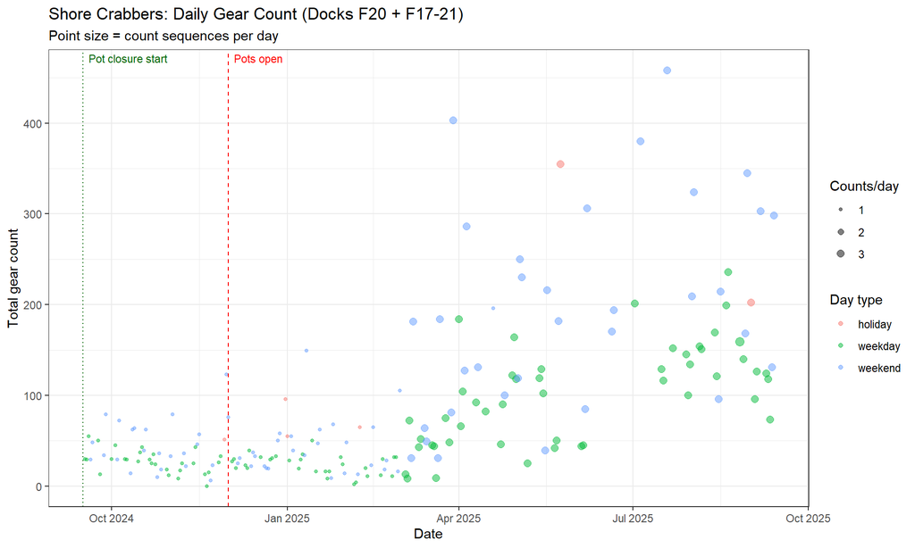

```r
# ---- 7.1 DIAGNOSTIC PLOTS ----
timer_start("2_diagnostic_plots")
message("\n", strrep("=",60), "\n DIAGNOSTIC PLOTS\n", strrep("=",60), "\n")

days_full <- prep_days_crab(params$est_date_start, params$est_date_end,
                            params, L_eff_model)

# Plot 1: Shore gear count timeseries
p_shore_effort <- dwg$shore_effort |>
  group_by(event_date) |>
  summarise(total_gear = sum(count_quantity), n_counts = n(), .groups = "drop") |>
  left_join(days_full |> select(event_date, day_type), by = "event_date") |>
  ggplot(aes(x = event_date, y = total_gear, color = day_type, size = n_counts)) +
  geom_point(alpha = 0.5) +
  pot_closure_markers(params, labels = TRUE) +
  scale_size_continuous(range = c(1,3), breaks = 1:3, name = "Counts/day") +
  labs(title = "Shore Crabbers: Daily Gear Count (Docks F20 + F17-21)",
       subtitle = "Point size = count sequences per day",
       x = "Date", y = "Total gear count", color = "Day type") +
  theme_bw()
ggsave(file.path(output_dir, "plot_shore_effort_timeseries.png"), p_shore_effort, width = 10, height = 6)
print(p_shore_effort)
```

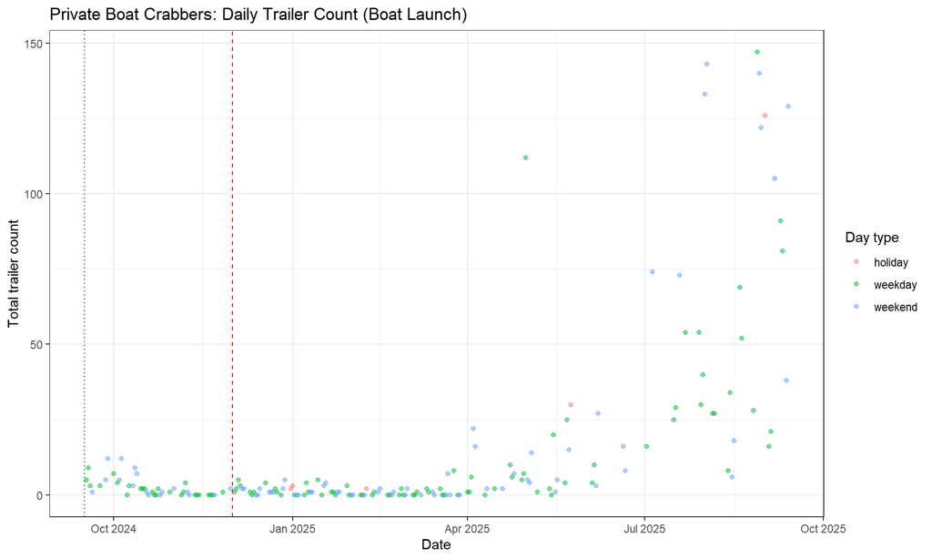

```r
# Plot 2: Boat trailer count timeseries
p_boat_effort <- dwg$boat_effort |>
  group_by(event_date) |>
  summarise(total_trailers = sum(count_quantity), n_counts = n(), .groups = "drop") |>
  left_join(days_full |> select(event_date, day_type), by = "event_date") |>
  ggplot(aes(x = event_date, y = total_trailers, color = day_type)) +
  geom_point(alpha = 0.5) +
  pot_closure_markers(params, labels = FALSE) +
  labs(title = "Private Boat Crabbers: Daily Trailer Count (Boat Launch)",
       x = "Date", y = "Total trailer count", color = "Day type") +
  theme_bw()
ggsave(file.path(output_dir, "plot_boat_effort_timeseries.png"), p_boat_effort, width = 10, height = 6)
print(p_boat_effort)
```

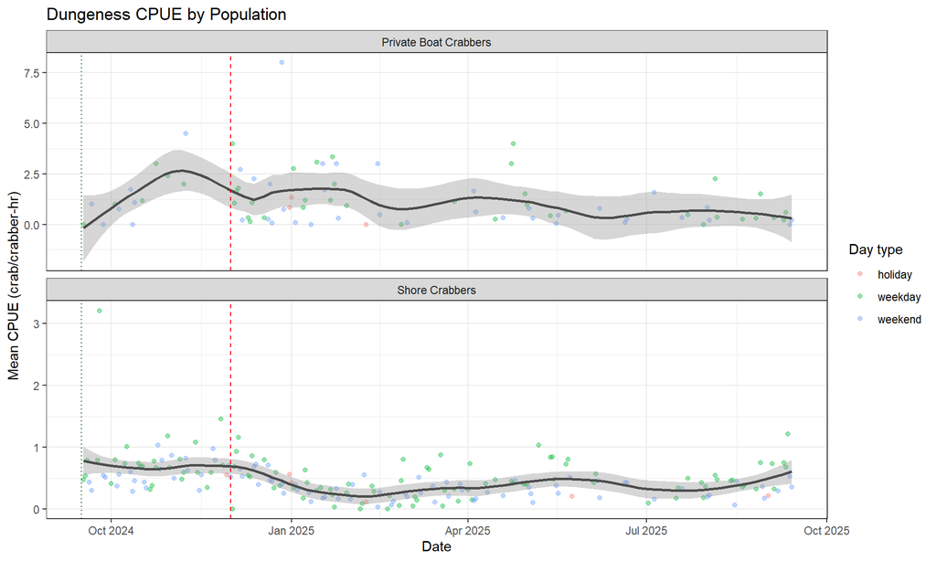

```r
# Plot 3: CPUE timeseries by population
cpue_data <- dwg$interview |>
  filter(fishing_time_total > 0, dungeness_kept >= 0) |>
  mutate(cpue = dungeness_kept / fishing_time_total) |>
  group_by(event_date, population) |>
  summarise(mean_cpue = mean(cpue), n_int = n(), .groups = "drop") |>
  left_join(days_full |> select(event_date, day_type), by = "event_date") |>
  filter(population %in% c("shore", "private_boat"))

p_cpue <- cpue_data |>
  ggplot(aes(x = event_date, y = mean_cpue, color = day_type)) +
  geom_point(alpha = 0.4, size = 1.5) +
  geom_smooth(method = "loess", span = 0.3, se = TRUE, color = "grey30") +
  pot_closure_markers(params, labels = FALSE) +
  facet_wrap(~population, ncol = 1, scales = "free_y",
             labeller = labeller(population = c(shore = "Shore Crabbers", private_boat = "Private Boat Crabbers"))) +
  labs(title = "Dungeness CPUE by Population",
       x = "Date", y = "Mean CPUE (crab/crabber-hr)", color = "Day type") +
  theme_bw()
ggsave(file.path(output_dir, "plot_cpue_timeseries.png"), p_cpue, width = 10, height = 8)
print(p_cpue)
```

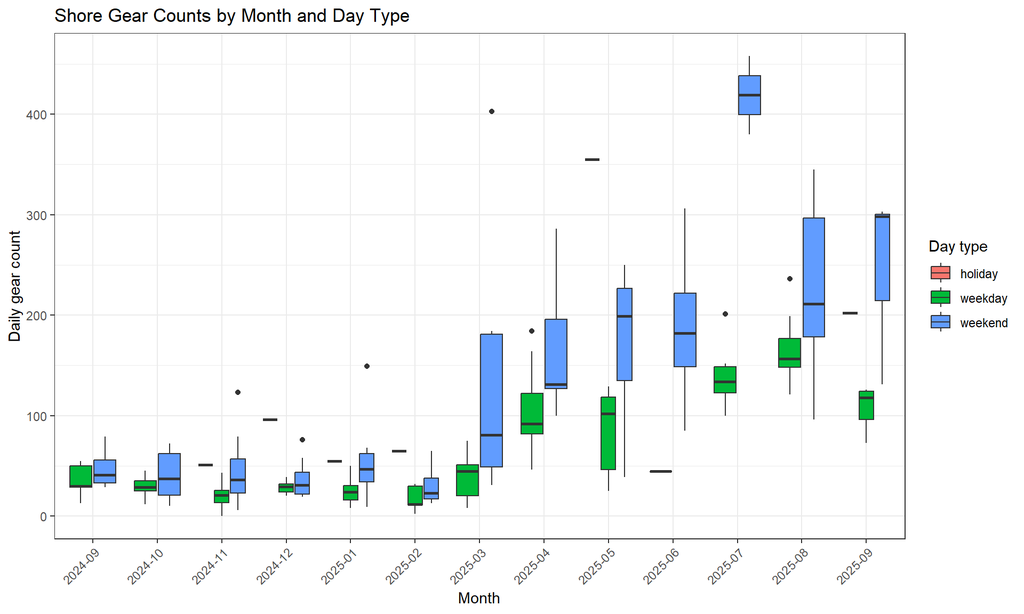

```r
# Plot 4: Gear counts by month and day type (boxplot)
p_effort_month <- dwg$shore_effort |>
  group_by(event_date) |>
  summarise(total_gear = sum(count_quantity), .groups = "drop") |>
  left_join(days_full |> select(event_date, day_type, month, year), by = "event_date") |>
  mutate(month_label = factor(format(event_date, "%Y-%m"))) |>
  ggplot(aes(x = month_label, y = total_gear, fill = day_type)) +
  geom_boxplot() +
  labs(title = "Shore Gear Counts by Month and Day Type",
       x = "Month", y = "Daily gear count", fill = "Day type") +
  theme_bw() +
  theme(axis.text.x = element_text(angle = 45, hjust = 1))
ggsave(file.path(output_dir, "plot_effort_by_month.png"), p_effort_month, width = 12, height = 6)
print(p_effort_month)
```

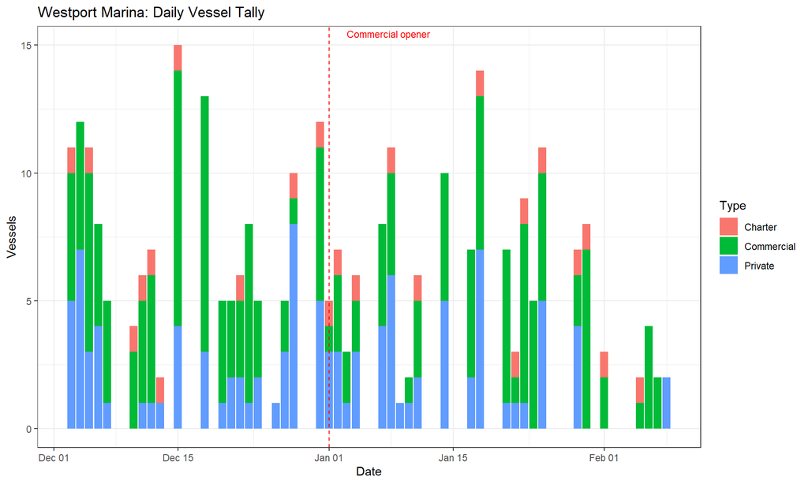

```r
# Plot 5: Commercial/charter vessel tally
if(nrow(dwg$comm_tally) > 0) {
  p_comm <- dwg$comm_tally |>
    pivot_longer(cols = c(commercial_tally, charter_tally, private_tally),
                 names_to = "vessel_type", values_to = "count") |>
    mutate(vessel_type = str_remove(vessel_type, "_tally") |> str_to_title()) |>
    ggplot(aes(x = date, y = count, fill = vessel_type)) +
    geom_col(position = "stack") +
    geom_vline(xintercept = as.Date(params$commercial_opener), linetype = "dashed", color = "red") +
    annotate("text", x = as.Date(params$commercial_opener) + 2, y = Inf,
             label = "Commercial opener", hjust = 0, vjust = 1.5, size = 3, color = "red") +
    labs(title = "Westport Marina: Daily Vessel Tally",
         x = "Date", y = "Vessels", fill = "Type") +
    theme_bw()
  ggsave(file.path(output_dir, "plot_commercial_tally.png"), p_comm, width = 10, height = 5)
  print(p_comm)
}
```

```r
message("  Diagnostic plots saved.\n")
timer_stop("2_diagnostic_plots")
```

```
##   [TIMER] 2_diagnostic_plots: 0.1 min
```

## 3. Point Estimator (PE)

The design-based estimator: it averages sampled days within each stat-week by day-type stratum and expands to the season, independently of the BSS. It is the model-free cross-check the gate can fall back to. This block also runs the commercial/charter census and the PE port totals.

```r
# ---- 7.2 PE ESTIMATES ----
timer_start("3_PE_estimates")
message("\n", strrep("=",60), "\n PE ESTIMATES\n", strrep("=",60), "\n")

pe_all <- list()
for(pop in c("shore","private_boat")) {
  for(ss in subseasons) {
    label <- paste0(pop, "_", ss$name)
    days_ss <- prep_days_crab(ss$start, ss$end, params, L_eff_model)
    summ_ss <- prep_population_summary(dwg, pop, ss$start, ss$end, params)
    pe_all[[label]] <- run_pe_gear(summ_ss, days_ss, params, label, population = pop)
  }
}
```

```
##
##   shore [2024-09-16 to 2024-11-30]: 52 effort obs, 856 interviews, crab/gear=0.76, R_G_empirical=1.32
##   PE check [shore_ring_net_only / Dungeness_Kept]: implied CPUE 1.3083 vs interview ratio-of-sums 1.2567 (1.04x) [gear-deployments]
##   PE shore_ring_net_only: Effort=4,486 gear-deployments, Dung=5,869
##
##   shore [2024-12-01 to 2025-09-15]: 313 effort obs, 2743 interviews, crab/gear=0.79, R_G_empirical=1.27
##   PE check [shore_all_gear / Dungeness_Kept]: implied CPUE 0.8653 vs interview ratio-of-sums 0.8706 (0.99x) [gear-deployments]
##   PE shore_all_gear: Effort=18,104 gear-deployments, Dung=15,665
##
##   private_boat [2024-09-16 to 2024-11-30]: 44 effort obs, 17 interviews, crab/gear=0.79, R_G_empirical=1.26
##   PE boat scale: gear_per_group=2.82, tau=1.20, mean f=1.000 (deployments, crab-directed)
##   PE check [private_boat_ring_net_only / Dungeness_Kept]: implied CPUE 2.0037 vs interview ratio-of-sums 2.2917 (0.87x) [gear-deployments]
##   PE private_boat_ring_net_only: Effort=584 gear-deployments, Dung=1,170
##
##   private_boat [2024-12-01 to 2025-09-15]: 196 effort obs, 145 interviews, crab/gear=0.82, R_G_empirical=1.22
##   PE boat scale: gear_per_group=3.55, tau=1.20, mean f=1.000 (deployments, crab-directed)
##   PE check [private_boat_all_gear / Dungeness_Kept]: implied CPUE 3.0682 vs interview ratio-of-sums 3.3570 (0.91x) [gear-deployments]
##   PE private_boat_all_gear: Effort=11,886 gear-deployments, Dung=36,468
```

```r
# ---- 7.3 PE PLOTS ----
message("\n  Generating PE plots...\n")

pe_daily_all <- list()
for(pop in c("shore","private_boat")) {
  for(ss in subseasons) {
    label <- paste0(pop, "_", ss$name)
    days_ss <- prep_days_crab(ss$start, ss$end, params, L_eff_model)
    summ_ss <- prep_population_summary(dwg, pop, ss$start, ss$end, params)

    # P1: this daily PE series must use the SAME effort basis as run_pe_gear(), or the
    # daily plots contradict the totals. It previously applied the shore
    # crabber-hours formula (crabbers x day_length) to the boat as well.
    is_shore_d <- (pop == "shore")
    spec_d <- bss_effort_spec(is_shore_d, days_ss, params)
    if(is_shore_d) {
      mult_d <- if(spec_d$effort_scale_gear == 1L) 1.0 else summ_ss$crabbers_per_gear
      Lcol_d <- if(spec_d$unit == "gear-deployments") (params$tau_shore_prior_mu %||% 1.7) else NA
    } else {
      ng_d   <- suppressWarnings(as.numeric(summ_ss$interview$number_of_gear))
      ng_d   <- ng_d[!is.na(ng_d) & ng_d > 0]
      mult_d <- if(length(ng_d) > 0) mean(ng_d) else (params$gear_per_group_default %||% 4.0)
      Lcol_d <- params$tau_boat_prior_mu %||% 1.2
    }

    de <- summ_ss$effort_index |>
      filter(count_sequence <= params$bss_max_count_seq) |>
      group_by(event_date, section_num) |>
      summarise(mean_count = mean(count_quantity), .groups = "drop") |>
      mutate(est_units = mean_count * mult_d) |>
      left_join(days_ss |> select(event_date, day_type, day_length), by = "event_date") |>
      mutate(L_d = if(is.na(Lcol_d)) day_length else Lcol_d,
             est_daily_effort = est_units * L_d,
             est_daily_crabber_hours = est_daily_effort,   # legacy name kept for plots
             effort_unit = spec_d$unit,
             population = pop, subseason = ss$name)
    pe_daily_all[[label]] <- de
  }
}
```

```
##
##   shore [2024-09-16 to 2024-11-30]: 52 effort obs, 856 interviews, crab/gear=0.76, R_G_empirical=1.32
##
##   shore [2024-12-01 to 2025-09-15]: 313 effort obs, 2743 interviews, crab/gear=0.79, R_G_empirical=1.27
##
##   private_boat [2024-09-16 to 2024-11-30]: 44 effort obs, 17 interviews, crab/gear=0.79, R_G_empirical=1.26
##
##   private_boat [2024-12-01 to 2025-09-15]: 196 effort obs, 145 interviews, crab/gear=0.82, R_G_empirical=1.22
```

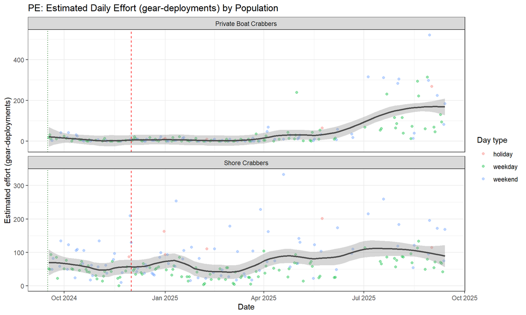

```r
pe_daily_df <- bind_rows(pe_daily_all)

p_pe_effort <- pe_daily_df |>
  mutate(pop_label = case_when(
    population == "shore" ~ "Shore Crabbers",
    population == "private_boat" ~ "Private Boat Crabbers")) |>
  ggplot(aes(x = event_date, y = est_daily_crabber_hours, color = day_type)) +
  geom_point(alpha = 0.4) +
  geom_smooth(method = "loess", span = 0.3, se = TRUE, color = "grey30") +
  pot_closure_markers(params, labels = FALSE) +
  facet_wrap(~pop_label, ncol = 1, scales = "free_y") +
  labs(title = "PE: Estimated Daily Effort (gear-deployments) by Population",
       x = "Date", y = "Estimated effort (gear-deployments)", color = "Day type") +
  theme_bw()
ggsave(file.path(output_dir, "plot_pe_daily_effort.png"), p_pe_effort, width = 10, height = 8)
print(p_pe_effort)
```

```r
timer_stop("3_PE_estimates")
```

```
##   [TIMER] 3_PE_estimates: 0.0 min
```

```r
# ---- 7.4 COMMERCIAL/CHARTER ----
timer_start("4_commercial_charter")
pe_all$comm_charter <- estimate_comm_charter(dwg, params)
```

```
##
## --- Commercial/Charter Census Estimation (Stratified) ---
##   Tally days: 47, Interviews: 160 (commercial 140, charter 20)
##   Mean Dungeness/vessel: commercial 39.3, charter 64.3
##
##   Stratified expansion by day type:
##     Day Type    Sampled  Total  Mean/day  Expanded
##     weekday        23       38    192.6       7319
##     weekend        24       32    145.8       4667
##
##   Est Dungeness (stratified): 11,986
```

```r
timer_stop("4_commercial_charter")
```

```
##   [TIMER] 4_commercial_charter: 0.0 min
```

```r
# ---- 7.5 PE PORT TOTALS ----
message("\n", strrep("=",60), "\n PE PORT TOTALS\n", strrep("=",60), "\n")

# component_keys / component_names now follow the sub-season set (build_subseasons):
# one row per population x sub-season, then comm_charter, then a PORT TOTAL computed from
# the semantic sums (pe_port_total), not by a fixed row index. component_keys is still
# consumed by the pe_summary build below.
pe_pops    <- c("shore", "private_boat")
pop_disp   <- c(shore = "Shore", private_boat = "Private Boat")
ss_names   <- vapply(subseasons, function(ss) ss$name,         character(1))
ss_disp    <- vapply(subseasons, function(ss) ss$display_name, character(1))
component_keys  <- c(unlist(lapply(pe_pops, function(p) paste0(p, "_", ss_names))), "comm_charter")
component_names <- c(unlist(lapply(pe_pops, function(p) sprintf("%s (%s)", pop_disp[[p]], ss_disp))),
                     "Commercial/Charter")

pe_summary <- tibble(
  Component  = c(component_names, "PORT TOTAL"),
  Effort_hrs = c(vapply(component_keys, function(k) pe_field(k, "effort_total"),  numeric(1)), pe_port_total("effort_total")),
  Dungeness  = c(vapply(component_keys, function(k) pe_field(k, "Dungeness_Kept"), numeric(1)), pe_port_total("Dungeness_Kept"))
)
if(params$estimate_red_rock) {
  pe_summary$Red_Rock <- c(vapply(component_keys, function(k) pe_field(k, "Red_Rock_Kept"), numeric(1)),
                           pe_port_total("Red_Rock_Kept"))
}

report_table(pe_summary |> mutate(across(where(is.numeric), ~round(.))), caption = "PE port totals by component")
```

PE port totals by component

| Component | Effort_hrs | Dungeness |
| --- | --- | --- |
| Shore (Pot closure) | 4,486 | 5,869 |
| Shore (All gear) | 18,104 | 15,665 |
| Private Boat (Pot closure) | 584 | 1,170 |
| Private Boat (All gear) | 11,886 | 36,468 |
| Commercial/Charter | 283 | 11,986 |
| PORT TOTAL | 35,342 | 71,157 |

```r
write.csv(pe_summary, file.path(output_dir, "pe_port_summary.csv"), row.names=FALSE)
```

## 4. Bayesian state-space model fits

Each population by sub-season is fit independently with a Bayesian state-space model: a latent AR(1) effort and CPUE process at a per-fit temporal resolution (capped per population so a thin series is not over-resolved), a negative-binomial observation model, and gear-deployment effort. Fitting is the slow step. **Healthy:** each fit with enough data samples without a wall of divergences; the convergence gate below is the formal check.

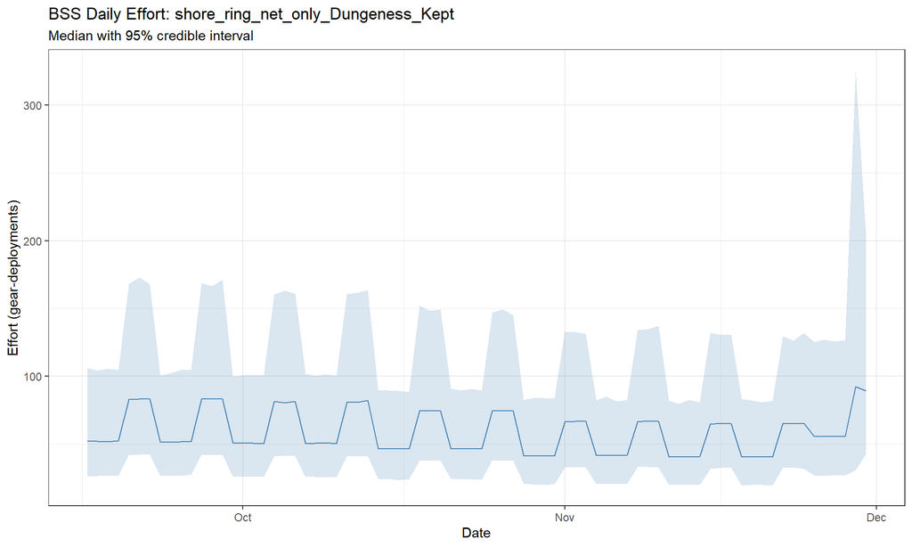

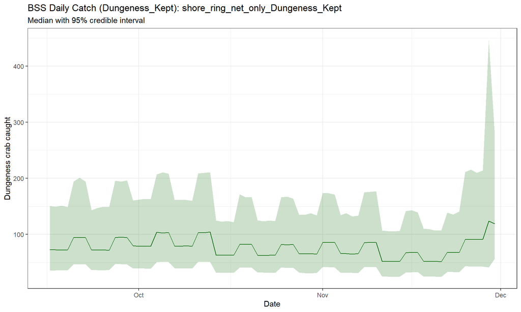

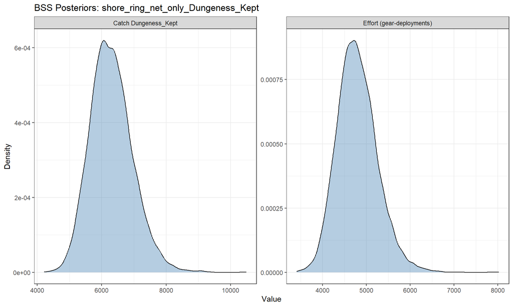

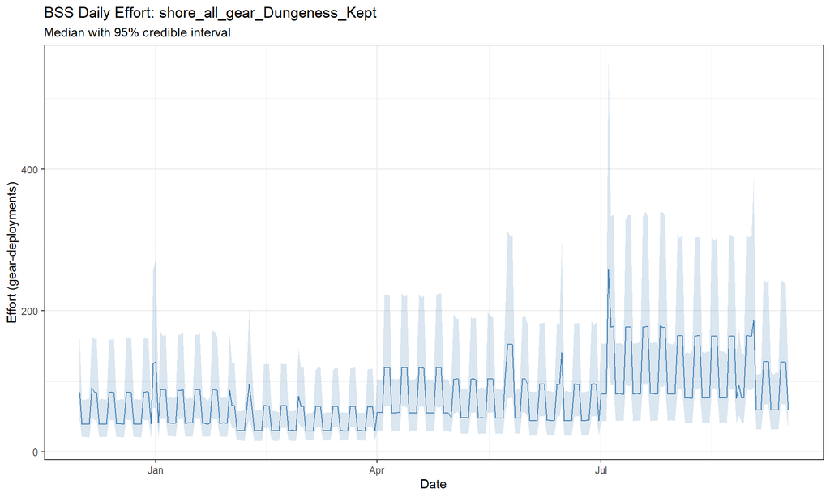

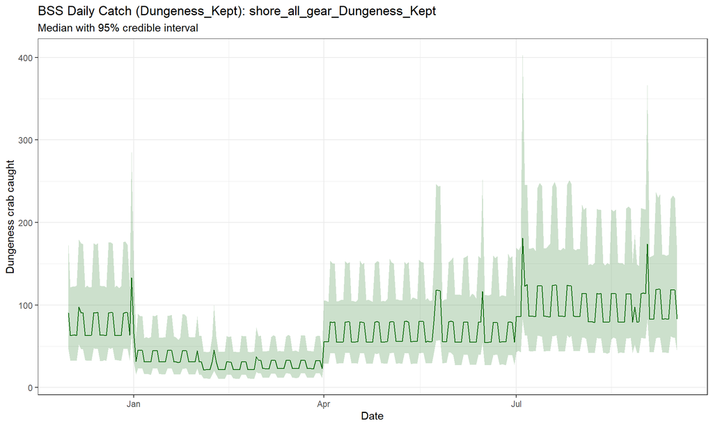

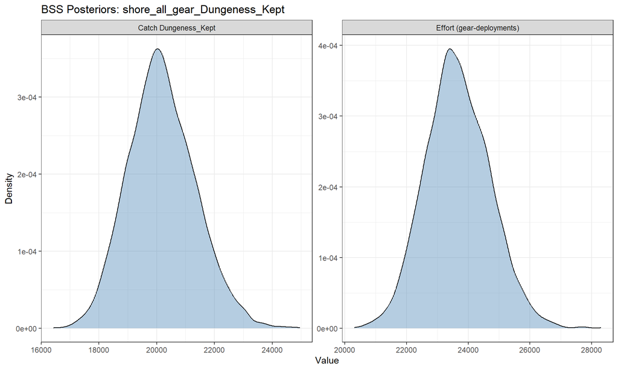

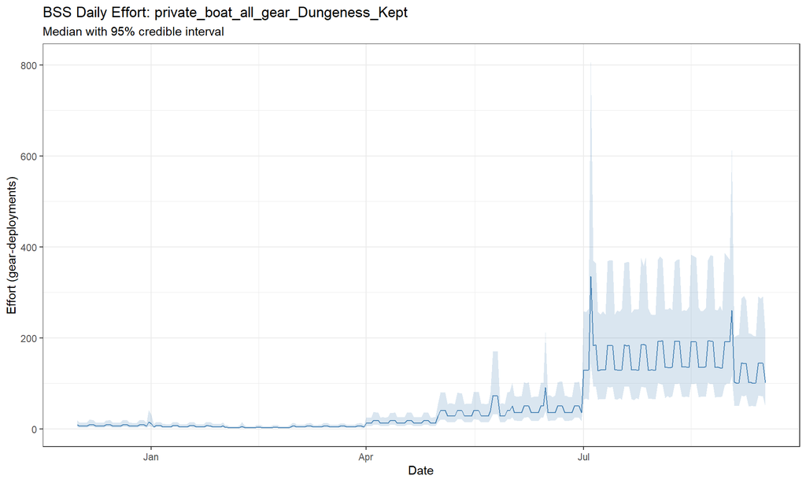

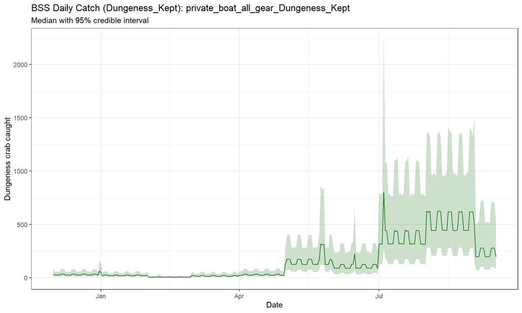

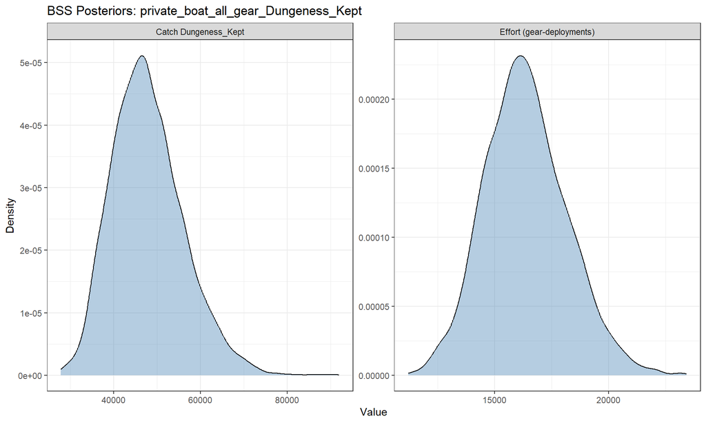

```r
# ---- 7.6 BSS MODEL RUNS ----
timer_start("5_BSS_model_runs")
message("\n", strrep("=",60), "\n BSS MODEL RUNS\n", strrep("=",60), "\n")

bss_catch_groups <- catch_groups
message(sprintf("Running BSS for: %s\n", paste(bss_catch_groups, collapse=", ")))

bss_all <- list()
ar_resolutions <- list()   # AR resolution actually used, per fit (for the gate report)
for(cg in bss_catch_groups) {
  for(pop in c("shore","private_boat")) {
    for(ss in subseasons) {
      label <- paste0(pop, "_", ss$name, "_", cg)
      message(sprintf("\n--- BSS: %s ---\n", label))

      days_ss <- prep_days_crab(ss$start, ss$end, params, L_eff_model)
      summ_ss <- prep_population_summary(dwg, pop, ss$start, ss$end, params)

      n_int <- nrow(summ_ss$interview)
      n_eff <- nrow(summ_ss$effort_index)

      if(n_eff < 5 || n_int < params$bss_min_interviews) {
        message(sprintf("  Insufficient data for BSS (%d effort, %d interviews < %d min), using PE only.\n",
                    n_eff, n_int, params$bss_min_interviews))
        bss_all[[label]] <- list(C_sum=NA, E_sum=NA, pe_fallback=TRUE,
                                 population=pop, subseason=ss$name, catch_group=cg)
        next
      }

      # v5.1: Pass sub-season-specific period type
      bss_data <- prep_bss_crab_gear(days_ss, summ_ss, cg, params, pop, ss$period_bss,
                                gear_exclude = ss$gear_exclude %||% character(0),
                                gear_regime = ss$gear_regime,
                                ie_data = ie_data)
      ar_resolutions[[label]] <- bss_data$.ar_resolution

      is_shore <- (pop == "shore")
      is_allgear <- (ss$gear_regime == "all_gear")
      is_ringnet <- (ss$gear_regime == "pot_closure")

      # Per-fit sampler tuning: shore all-gear is the most complex posterior
      # (4 gear types, 10 monthly periods); pot-closure fits are data-sparse
      # and benefit from tighter adaptation. All other fits use defaults.
      if(is_shore && is_allgear) {
        fit_iter    <- params$bss_iter_shore_allgear
        fit_warmup  <- params$bss_warmup_shore_allgear
        fit_treedep <- params$bss_treedepth_shore_allgear %||% params$bss_max_treedepth_default
        fit_delta   <- params$bss_delta_shore_allgear %||% params$bss_adapt_delta_default
      } else if(is_ringnet) {
        fit_iter    <- params$bss_iter_ringnet %||% params$bss_iter_default
        fit_warmup  <- params$bss_warmup_ringnet %||% params$bss_warmup_default
        fit_treedep <- params$bss_treedepth_ringnet %||% params$bss_max_treedepth_default
        fit_delta   <- params$bss_delta_ringnet %||% params$bss_adapt_delta_default
      } else {
        fit_iter    <- params$bss_iter_default
        fit_warmup  <- params$bss_warmup_default
        fit_treedep <- params$bss_max_treedepth_default
        fit_delta   <- params$bss_adapt_delta_default
      }

      message(sprintf("  Stan settings: iter=%d, warmup=%d, max_treedepth=%d, adapt_delta=%.2f\n",
                  fit_iter, fit_warmup, fit_treedep, fit_delta))

      timer_start(paste0("BSS_", label))
      fit <- rstan::stan(
        file = here("02_stan_models", params$bss_model_file),
        data = bss_data,
        chains = params$bss_chains, iter = fit_iter, warmup = fit_warmup,
        control = list(adapt_delta = fit_delta, max_treedepth = fit_treedep),
        seed = params$bss_seed,   # was missing: gear-resolved fits were not reproducible
        cores = params$bss_cores
      )
      timer_stop(paste0("BSS_", label))

      # --- Extract and save BSS summary ---
      # C_sum_gear is the predictive season total per gear. With G = 1 it is a
      # single 'All' column and sum(C_sum_gear) == C_sum. The Dirichlet pi_gear
      # machinery described in older comments is not present in the Stan model.
      bss_summ <- summary(fit, pars=c("C_sum","E_sum","C_sum_gear","B1","B2",
                                       "r_C_gear_out","sigma_eps_C_gear_out"))$summary
      message("  BSS Summary:\n"); print(bss_summ)
      write.csv(as.data.frame(bss_summ), file.path(output_dir, paste0("bss_summary_",label,".csv")))

      C_draws <- rstan::extract(fit, "C_sum")$C_sum
      E_draws <- rstan::extract(fit, "E_sum")$E_sum

      C_gear_draws <- rstan::extract(fit, "C_sum_gear")$C_sum_gear  # [draws, G_gear]
      gear_labels <- bss_data$.gear_type_labels

      bss_all[[label]] <- list(
        C_sum = quantile(C_draws, c(0.025,0.5,0.975)),
        E_sum = quantile(E_draws, c(0.025,0.5,0.975)),
        C_draws = C_draws, E_draws = E_draws,
        C_gear_draws = C_gear_draws,
        gear_type_labels = gear_labels,
        fit = fit, pe_fallback = FALSE,
        # Carried for the shared diagnostics in 03_R_functions (PPC, effort
        # overdispersion decomposition, O1-O13, PSIS-LOO). Without these the
        # writers silently skip, so they are stored on the fit entry.
        bss_data = bss_data, days_ss = days_ss,
        population = pop, subseason = ss$name, catch_group = cg
      )

      # --- BSS PLOTS for this fit ---

      # Daily effort posteriors (ribbon plot)
      E_bss <- rstan::extract(fit, "E")$E  # [draws, S, D, G]
      E_daily <- tibble(
        event_date = days_ss$event_date,
        median = apply(E_bss[,1,,1], 2, median),
        lo95 = apply(E_bss[,1,,1], 2, quantile, 0.025),
        hi95 = apply(E_bss[,1,,1], 2, quantile, 0.975)
      )

      p_bss_eff <- E_daily |>
        left_join(days_ss |> select(event_date, day_type), by = "event_date") |>
        ggplot(aes(x = event_date)) +
        geom_ribbon(aes(ymin = lo95, ymax = hi95), alpha = 0.2, fill = "steelblue") +
        geom_line(aes(y = median), color = "steelblue") +
        labs(title = sprintf("BSS Daily Effort: %s", label),
             subtitle = "Median with 95% credible interval",
             x = "Date", y = "Effort (gear-deployments)") +
        theme_bw()
      ggsave(file.path(output_dir, paste0("plot_bss_effort_", label, ".png")),
             p_bss_eff, width = 10, height = 6)
      print(p_bss_eff)

      # Daily catch posteriors
      # v5.2: C_total is now the expected value (smooth trajectory, no Poisson noise).
      # Uses C_total for trajectory plots; C_gear_pred used for season totals.
      C_total_bss <- rstan::extract(fit, "C_total")$C_total  # [draws, D]
      C_daily <- tibble(
        event_date = days_ss$event_date,
        median = apply(C_total_bss, 2, median),
        lo95 = apply(C_total_bss, 2, quantile, 0.025),
        hi95 = apply(C_total_bss, 2, quantile, 0.975)
      )

      p_bss_catch <- C_daily |>
        ggplot(aes(x = event_date)) +
        geom_ribbon(aes(ymin = lo95, ymax = hi95), alpha = 0.2, fill = "darkgreen") +
        geom_line(aes(y = median), color = "darkgreen") +
        labs(title = sprintf("BSS Daily Catch (%s): %s", cg, label),
             subtitle = "Median with 95% credible interval",
             x = "Date", y = "Dungeness crab caught") +
        theme_bw()
      ggsave(file.path(output_dir, paste0("plot_bss_catch_", label, ".png")),
             p_bss_catch, width = 10, height = 6)
      print(p_bss_catch)

      # Season total posterior densities
      p_bss_post <- tibble(C_sum = C_draws, E_sum = E_draws) |>
        pivot_longer(everything(), names_to = "param", values_to = "value") |>
        ggplot(aes(x = value)) +
        geom_density(fill = "steelblue", alpha = 0.4) +
        facet_wrap(~param, scales = "free", labeller = labeller(
          param = c(C_sum = paste("Catch", cg), E_sum = "Effort (gear-deployments)")
        )) +
        labs(title = sprintf("BSS Posteriors: %s", label), x = "Value", y = "Density") +
        theme_bw()
      ggsave(file.path(output_dir, paste0("plot_bss_posteriors_", label, ".png")),
             p_bss_post, width = 12, height = 5)
      print(p_bss_post)

      # Save daily CSVs
      write.csv(E_daily, file.path(output_dir, paste0("bss_daily_effort_", label, ".csv")), row.names=FALSE)
      write.csv(C_daily, file.path(output_dir, paste0("bss_daily_catch_", label, ".csv")), row.names=FALSE)

    }
  }
}
```

```r
timer_stop("5_BSS_model_runs")
```

## 5. Convergence gate and model selection

The scale-aware gate decides, per fit, whether to report the Bayesian posterior or fall back to the PE. A fit passes only if R-hat is below 1.01, effective sample size is above 400, the divergent fraction is under the backstop, and the divergent draws do not move the reported totals by more than 0.10 posterior standard deviations. **If a component reads PE here, its Bayesian fit did not clear the gate;** that is expected for data-thin components and is not an error.

```r
# ---- 7.6b CONVERGENCE GATE (B1.8, scale-aware; shared in 03_R_functions) ----
# Decide PE-vs-BSS per fit BEFORE any reported total is assembled. bss_compute_gate
# and bss_use_pe_for live in 03_R_functions/bss_convergence_gate.R (shared with the
# pooled track). A fit reports BSS only if it passes the gate; otherwise the
# reported-estimate sections below fall back to PE. Diagnostic sections still key
# off pe_fallback so a fitted-but-gate-failed component keeps its per-fit outputs.
message("\n", strrep("=",60), "\n CONVERGENCE GATE\n", strrep("=",60), "\n")
for(label in names(bss_all)) {
  gi <- bss_compute_gate(
    bss_all[[label]], label,
    catch_par        = "C_expected_sum",
    effort_par       = "E_sum",
    max_impact_sd    = params$max_divergence_total_impact_sd %||% 0.10,
    max_div_fraction = params$max_divergence_fraction %||% 0.05,
    ar_resolution    = ar_resolutions[[label]] %||% NA_character_
  )
  bss_all[[label]]$gate_info <- gi
  bss_all[[label]]$use_bss   <- isTRUE(gi$pass_convergence)
}
```

```
##   shore_ring_net_only_Dungeness_Kept: 22/8000 divergent (0.3%); impact C/E = 0.0002/0.0000 SD; level-distortion C/E = 1.0%/0.1%
##   shore_all_gear_Dungeness_Kept: 19/8000 divergent (0.2%); impact C/E = 0.0006/0.0005 SD; level-distortion C/E = 2.3%/0.8%
##   private_boat_all_gear_Dungeness_Kept: 15/4000 divergent (0.4%); impact C/E = 0.0000/0.0003 SD; level-distortion C/E = 0.2%/0.7%
```

## 6. Headline result: port total

The season harvest estimate: the sum of all components, reported as expected catch with a 95 percent credible interval. This is the number to cite, read together with the convergence and PE-vs-BSS sections. Components that passed the gate contribute their Bayesian posterior; components that did not contribute their PE point. **Cross-check:** the port total and the boat should land within a few percent of the pooled CPUE model’s run.

```r
# ---- 7.7 COMBINED BSS PORT TOTAL ----
timer_start("6_outputs")
message("\n", strrep("=",60), "\n COMBINED RESULTS\n", strrep("=",60), "\n")

n_draws_max <- max(sapply(bss_all, function(b) {
  if(bss_use_pe_for(b)) return(0)   # B1.8: a gate-failed fit contributes no BSS draws
  length(b$C_draws)
}))
if(n_draws_max == 0) n_draws_max <- params$bss_chains * (params$bss_iter_default - params$bss_warmup_default)

for(cg in bss_catch_groups) {
  bss_C_total <- rep(0, n_draws_max)
  bss_E_total <- rep(0, n_draws_max)

  for(pop in c("shore","private_boat")) {
    for(ss in subseasons) {
      label <- paste0(pop, "_", ss$name, "_", cg)
      pe_label <- paste0(pop, "_", ss$name)
      b <- bss_all[[label]]

      if(bss_use_pe_for(b)) {   # B1.8: PE if insufficient data OR failed the gate
        bss_C_total <- bss_C_total + (pe_all[[pe_label]][[cg]] %||% 0)
        bss_E_total <- bss_E_total + pe_all[[pe_label]]$effort_total
      } else {
        n <- length(b$C_draws)
        idx <- rep_len(1:n, n_draws_max)
        bss_C_total <- bss_C_total + b$C_draws[idx]
        bss_E_total <- bss_E_total + b$E_draws[idx]
      }
    }
  }
  bss_C_total <- bss_C_total + (pe_all$comm_charter[[cg]] %||% 0)
  bss_E_total <- bss_E_total + pe_all$comm_charter$effort_total

  final_table <- tibble(
    Catch_Group = cg,
    Estimate = c("Effort (gear-deployments)", "Catch"),
    PE = c(round(pe_port_total("effort_total")),
           round(if(cg=="Dungeness_Kept") pe_port_total("Dungeness_Kept") else pe_port_total("Red_Rock_Kept"))),
    BSS_median = c(round(median(bss_E_total)), round(median(bss_C_total))),
    BSS_lo95 = c(round(quantile(bss_E_total,0.025)), round(quantile(bss_C_total,0.025))),
    BSS_hi95 = c(round(quantile(bss_E_total,0.975)), round(quantile(bss_C_total,0.975)))
    ,
    # F5: this column is NOT pure BSS. It is the gate-selected combination:
    # BSS draws where the convergence gate passed, PE where it failed or data
    # were insufficient, and the commercial/charter census. As of v5.5 both shore
    # and boat effort are on gear-deployments, so the Effort row is a single unit.
    composition = "BSS where gate passed; PE otherwise; census for comm/charter",
    effort_units_note = "Effort row is gear-deployments for both shore and boat (v5.5+)"
  )

  message(sprintf("\n--- Port Total: %s ---\n", cg))
  write.csv(final_table, file.path(output_dir, paste0("port_total_",cg,".csv")), row.names=FALSE)
  if (cg == "Dungeness_Kept") {
    .port_total_disp  <- final_table
    .tau_port_draws   <- bss_C_total   # combined port catch draws (for the tau diagnostic)
  }
}

# Headline table as a clean captioned table (auto-printed at chunk top level).
if (exists(".port_total_disp")) report_table(.port_total_disp,
  caption = "Port total: PE, BSS median, and 95% credible interval (combined effort and catch)")
```

Port total: PE, BSS median, and 95% credible interval (combined effort and catch)

| Catch_Group | Estimate | PE | BSS_median | BSS_lo95 | BSS_hi95 | composition | effort_units_note |
| --- | --- | --- | --- | --- | --- | --- | --- |
| Dungeness_Kept | Effort (gear-deployments) | 35,342 | 45,623 | 41,750 | 50,015 | BSS where gate passed; PE otherwise; census for comm/charter | Effort row is gear-deployments for both shore and boat (v5.5+) |
| Dungeness_Kept | Catch | 71,157 | 86,817 | 73,424 | 105,724 | BSS where gate passed; PE otherwise; census for comm/charter | Effort row is gear-deployments for both shore and boat (v5.5+) |

## 6b. Boat `tau_boat` prior sensitivity (optional)

The boat harvest is proportional to the boat deployment turnover `tau_boat` whenever no in-window boat ingress/egress days pin it (the 2024-25 case: 0 boat I/E days, so the boat total rests on the `tau_boat` prior, GR-12). With `run_config$diagnose_tau_sensitivity = TRUE` this section projects the boat and port totals across a grid of `tau_boat` prior means **in a single run (no refit)**, and states whether the projection is exact (tau prior-dominated) or an upper bound. For the exact multi-refit check, source `06_diagnostics/run_tau_sweep.R`. **Healthy:** if the boat scales ~linearly with `tau_boat`, the boat is prior-driven and the field priority is boat I/E (egress-classification) coverage; if it barely moves, tau is data-identified and the prior is not the lever.

```r
if (isTRUE(params$diagnose_tau_sensitivity)) {
  boat_key <- "private_boat_all_gear_Dungeness_Kept"
  b_boat   <- bss_all[[boat_key]]
  if (!is.null(b_boat) && !bss_use_pe_for(b_boat) && exists(".tau_port_draws")) {
    n_draws_max <- length(.tau_port_draws)
    nb          <- length(b_boat$C_draws)
    # Boat's aligned contribution to the port draws (same alignment as sec 6), so
    # the projection swaps only the boat term.
    boat_draws  <- b_boat$C_draws[rep_len(1:nb, n_draws_max)]
    n_ie_boat   <- tryCatch(as.integer(b_boat$n_ie_obs %||% 0L), error = function(e) 0L)
    tau_sens <- diagnose_tau_boat_sensitivity(
      boat = b_boat, port_C_draws = .tau_port_draws, boat_C_draws = boat_draws,
      params = params, n_ie_boat = n_ie_boat, output_dir = output_dir)
    if (!is.null(tau_sens$table)) {
      cat(paste(knitr::kable(
        tau_sens$table |> dplyr::select(tau_boat_prior_mu, boat_catch_median,
          boat_lo95, boat_hi95, boat_pct_change, port_total_median, port_pct_change),
        caption = "Projected boat and port totals across the tau_boat prior grid.",
        format.args = list(big.mark = ",")), collapse = "\n"), "\n\n")
      cat("*", tau_sens$note, "*\n\n", sep = "")
    } else {
      cat("_", tau_sens$note, "_\n\n", sep = "")
    }
  } else {
    cat("_Boat tau sensitivity not applicable (boat used the PE fallback, or no port draws were stashed)._\n\n")
  }
} else {
  cat("_Set `diagnose_tau_sensitivity = TRUE` in run_config.R to project the boat and port sensitivity to the `tau_boat` prior (single run, no refit). Writes `tau_boat_sensitivity.csv`._\n\n")
}
```

Projected boat and port totals across the tau_boat prior grid.

| tau_boat_prior_mu | boat_catch_median | boat_lo95 | boat_hi95 | boat_pct_change | port_total_median | port_pct_change |
| --- | --- | --- | --- | --- | --- | --- |
| 0.9 | 35,344 | 25,721 | 49,462 | -25.0 | 75,023 | -13.6 |
| 1.0 | 39,271 | 28,579 | 54,958 | -16.7 | 78,951 | -9.1 |
| 1.2 | 47,126 | 34,295 | 65,950 | 0.0 | 86,817 | 0.0 |
| 1.5 | 58,907 | 42,869 | 82,437 | 25.0 | 98,539 | 13.5 |
| 1.8 | 70,688 | 51,442 | 98,925 | 50.0 | 110,327 | 27.1 |

## 7. Monthly estimates

The season total broken out by month, with per-month credible intervals, showing the within-season trajectory. **Healthy:** the widest intervals fall on the thinly sampled summer months, where the process model imputes the most.

```r
# ===========================================================================
# 7.8 MONTHLY ESTIMATES WITH UNCERTAINTY
# v5.1: Uses C_total (vector[D]) instead of C[S][D,G]
# ===========================================================================

message("\n", strrep("=",60), "\n MONTHLY ESTIMATES\n", strrep("=",60), "\n")

days_full <- prep_days_crab(params$est_date_start, params$est_date_end,
                            params, L_eff_model)

month_lookup <- days_full |>
  mutate(month_label = format(event_date, "%Y-%m")) |>
  select(event_date, month_label)

all_months <- sort(unique(month_lookup$month_label))
monthly_C_draws <- matrix(0, nrow = n_draws_max, ncol = length(all_months),
                          dimnames = list(NULL, all_months))
monthly_E_draws <- matrix(0, nrow = n_draws_max, ncol = length(all_months),
                          dimnames = list(NULL, all_months))

for(cg in bss_catch_groups) {
  for(pop in c("shore","private_boat")) {
    for(ss in subseasons) {
      label <- paste0(pop, "_", ss$name, "_", cg)
      pe_label <- paste0(pop, "_", ss$name)
      b <- bss_all[[label]]

      days_ss <- prep_days_crab(ss$start, ss$end, params, L_eff_model)
      days_ss$month_label <- format(days_ss$event_date, "%Y-%m")

      if(bss_use_pe_for(b)) {   # B1.8: PE if insufficient data OR failed the gate
        summ_ss <- prep_population_summary(dwg, pop, ss$start, ss$end, params)
        # T4.4: shared monthly effort-share helper (03_R_functions/pe_monthly_effort_share.R).
        # Population-aware, so the boat PE-fallback now gets its deployment-scale effort
        # here instead of the shore crabber-hours formula this block used inline before.
        monthly_pe <- pe_monthly_effort_share(pop, summ_ss, days_ss, params)

        pe_catch_total <- pe_all[[pe_label]][[cg]] %||% 0
        pe_effort_total <- pe_all[[pe_label]]$effort_total

        for(m in monthly_pe$month_label) {
          if(m %in% all_months) {
            sh <- monthly_pe$share[monthly_pe$month_label == m]
            monthly_C_draws[, m] <- monthly_C_draws[, m] + pe_catch_total * sh
            monthly_E_draws[, m] <- monthly_E_draws[, m] + pe_effort_total * sh
          }
        }

      } else {
        # Use C_gear_pred (predictive, carries Poisson noise) for monthly
        # totals so predictive uncertainty propagates into monthly CIs.
        # C_total is now expected value (smooth) - good for daily plots but
        # would underestimate monthly CI widths.
        C_pred_mat <- rstan::extract(b$fit, "C_gear_pred")$C_gear_pred  # [draws, D, G_gear]
        # Sum across gear types to get daily total with full uncertainty
        C_daily_mat <- apply(C_pred_mat, c(1, 2), sum)  # [draws, D]
        E_bss <- rstan::extract(b$fit, "E")$E  # [draws, S, D, G]
        E_daily_mat <- E_bss[,1,,1]
        n_fit_draws <- nrow(C_daily_mat)

        for(m in unique(days_ss$month_label)) {
          day_idx <- which(days_ss$month_label == m)
          if(length(day_idx) == 0) next

          if(length(day_idx) == 1) {
            month_C <- C_daily_mat[, day_idx]
            month_E <- E_daily_mat[, day_idx]
          } else {
            month_C <- rowSums(C_daily_mat[, day_idx])
            month_E <- rowSums(E_daily_mat[, day_idx])
          }

          idx <- rep_len(1:n_fit_draws, n_draws_max)
          if(m %in% all_months) {
            monthly_C_draws[, m] <- monthly_C_draws[, m] + month_C[idx]
            monthly_E_draws[, m] <- monthly_E_draws[, m] + month_E[idx]
          }
        }
      }
    }
  }
}
```

```
##
##   private_boat [2024-09-16 to 2024-11-30]: 44 effort obs, 17 interviews, crab/gear=0.79, R_G_empirical=1.26
```

```r
# Add commercial/charter to census months
if(!is.null(pe_all$comm_charter$daily_est)) {
  comm_daily <- pe_all$comm_charter$daily_est |>
    mutate(month_label = format(date, "%Y-%m"))

  comm_total <- pe_all$comm_charter$Dungeness_Kept
  total_sampled_dung <- sum(comm_daily$est_dung)
  if(total_sampled_dung > 0) {
    for(m in unique(comm_daily$month_label)) {
      if(m %in% all_months) {
        share <- sum(comm_daily$est_dung[comm_daily$month_label == m]) / total_sampled_dung
        monthly_C_draws[, m] <- monthly_C_draws[, m] + comm_total * share
      }
    }
  }
}

monthly_summary <- tibble(
  Month = all_months,
  BSS_Catch_median = apply(monthly_C_draws, 2, median),
  BSS_Catch_lo95   = apply(monthly_C_draws, 2, quantile, 0.025),
  BSS_Catch_hi95   = apply(monthly_C_draws, 2, quantile, 0.975),
  BSS_Effort_median = apply(monthly_E_draws, 2, median),
  BSS_Effort_lo95   = apply(monthly_E_draws, 2, quantile, 0.025),
  BSS_Effort_hi95   = apply(monthly_E_draws, 2, quantile, 0.975)
) |>
  mutate(across(where(is.numeric), round))

message("\n--- Monthly Dungeness Catch Estimates (all populations combined) ---\n")
report_table(monthly_summary |> select(Month, BSS_Catch_median, BSS_Catch_lo95, BSS_Catch_hi95), caption = "Monthly Dungeness catch (all populations combined)")
```

Monthly Dungeness catch (all populations combined)

| Month | BSS_Catch_median | BSS_Catch_lo95 | BSS_Catch_hi95 |
| --- | --- | --- | --- |
| 2024-09 | 1,674 | 1,294 | 2,319 |
| 2024-10 | 3,225 | 2,650 | 3,984 |
| 2024-11 | 2,482 | 1,905 | 3,282 |
| 2024-12 | 9,618 | 8,793 | 10,750 |
| 2025-01 | 7,163 | 6,665 | 7,909 |
| 2025-02 | 1,683 | 1,386 | 2,129 |
| 2025-03 | 1,462 | 1,067 | 2,151 |
| 2025-04 | 2,966 | 2,270 | 4,041 |
| 2025-05 | 7,624 | 5,300 | 11,821 |
| 2025-06 | 5,582 | 3,516 | 9,407 |
| 2025-07 | 15,637 | 9,472 | 27,658 |
| 2025-08 | 20,411 | 13,653 | 31,431 |
| 2025-09 | 5,614 | 3,345 | 9,955 |

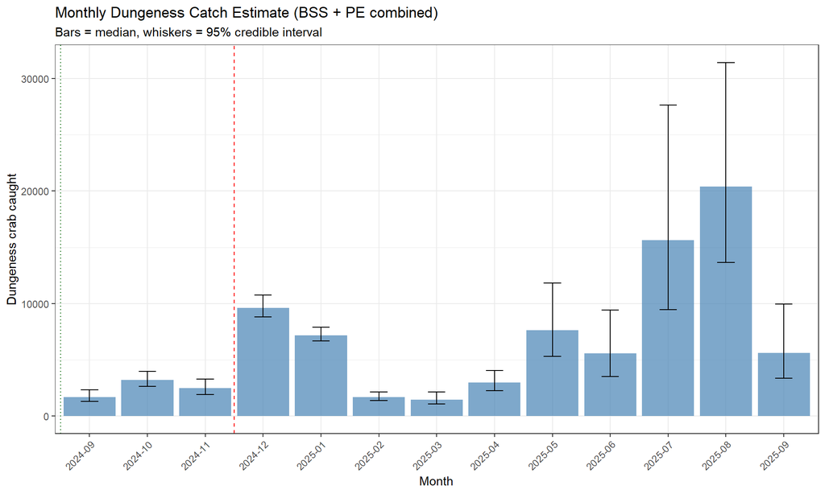

```r
write.csv(monthly_summary, file.path(output_dir, "monthly_estimates.csv"), row.names = FALSE)

# Monthly catch plot
p_monthly <- monthly_summary |>
  mutate(Month = factor(Month, levels = all_months)) |>
  ggplot(aes(x = Month)) +
  geom_col(aes(y = BSS_Catch_median), fill = "steelblue", alpha = 0.7) +
  geom_errorbar(aes(ymin = BSS_Catch_lo95, ymax = BSS_Catch_hi95), width = 0.3) +
  geom_vline(xintercept = which(all_months == format(as.Date(params$pot_closure_start %||% params$est_date_start), "%Y-%m")) - 0.5,
             linetype = "dotted", color = "darkgreen") +
  geom_vline(xintercept = which(all_months == format(as.Date(params$pot_open_date), "%Y-%m")) - 0.5,
             linetype = "dashed", color = "red") +
  labs(title = "Monthly Dungeness Catch Estimate (BSS + PE combined)",
       subtitle = "Bars = median, whiskers = 95% credible interval",
       x = "Month", y = "Dungeness crab caught") +
  theme_bw() +
  theme(axis.text.x = element_text(angle = 45, hjust = 1))
ggsave(file.path(output_dir, "plot_monthly_catch.png"), p_monthly, width = 12, height = 6)
print(p_monthly)
```

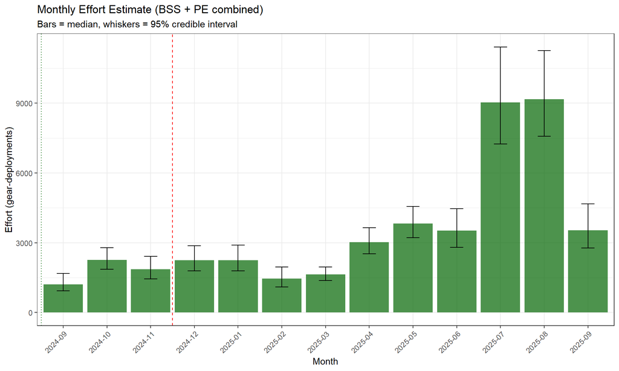

```r
# Monthly effort plot
p_monthly_eff <- monthly_summary |>
  mutate(Month = factor(Month, levels = all_months)) |>
  ggplot(aes(x = Month)) +
  geom_col(aes(y = BSS_Effort_median), fill = "darkgreen", alpha = 0.7) +
  geom_errorbar(aes(ymin = BSS_Effort_lo95, ymax = BSS_Effort_hi95), width = 0.3) +
  geom_vline(xintercept = which(all_months == format(as.Date(params$pot_closure_start %||% params$est_date_start), "%Y-%m")) - 0.5,
             linetype = "dotted", color = "darkgreen") +
  geom_vline(xintercept = which(all_months == format(as.Date(params$pot_open_date), "%Y-%m")) - 0.5,
             linetype = "dashed", color = "red") +
  labs(title = "Monthly Effort Estimate (BSS + PE combined)",
       subtitle = "Bars = median, whiskers = 95% credible interval",
       x = "Month", y = "Effort (gear-deployments)") +
  theme_bw() +
  theme(axis.text.x = element_text(angle = 45, hjust = 1))
ggsave(file.path(output_dir, "plot_monthly_effort.png"), p_monthly_eff, width = 12, height = 6)
print(p_monthly_eff)
```

## 8. Catch by crabbing mode

```r
# ===========================================================================
# 7.9 CATCH BY CRABBING MODE
# ===========================================================================

message("\n", strrep("=",60), "\n CATCH BY CRABBING MODE\n", strrep("=",60), "\n")

mode_table <- tibble(
  Mode = c("Shore (Dock/Jetty/Beach)", "Private Boat", "Commercial/Charter", "PORT TOTAL"),
  PE_Catch = c(
    pe_pop_sum("shore", "Dungeness_Kept"),
    pe_pop_sum("private_boat", "Dungeness_Kept"),
    pe_field("comm_charter", "Dungeness_Kept"),
    NA
  ),
  PE_Effort = c(
    pe_pop_sum("shore", "effort_total"),
    pe_pop_sum("private_boat", "effort_total"),
    pe_field("comm_charter", "effort_total"),
    NA
  )
)
mode_table$PE_Catch[4] <- sum(mode_table$PE_Catch[1:3], na.rm = TRUE)
mode_table$PE_Effort[4] <- sum(mode_table$PE_Effort[1:3], na.rm = TRUE)

report_table(mode_table |> mutate(across(where(is.numeric), round)), caption = "Catch by crabbing mode (PE)")
```

Catch by crabbing mode (PE)

| Mode | PE_Catch | PE_Effort |
| --- | --- | --- |
| Shore (Dock/Jetty/Beach) | 21,533 | 22,590 |
| Private Boat | 37,638 | 12,470 |
| Commercial/Charter | 11,986 | 283 |
| PORT TOTAL | 71,157 | 35,342 |

```r
write.csv(mode_table, file.path(output_dir, "catch_by_mode.csv"), row.names = FALSE)
```

## 9. Catch by gear type

```r
# ===========================================================================
# 7.10 BSS CATCH BY GEAR TYPE
# v5.1: PE fallback uses word-boundary regex consistent with BSS
# ===========================================================================

message("\n", strrep("=",60), "\n BSS CATCH BY GEAR TYPE\n", strrep("=",60), "\n")

gear_results <- list()

for(pop in c("shore","private_boat")) {
  for(ss in subseasons) {
    label_cg <- paste0(pop, "_", ss$name, "_Dungeness_Kept")
    pe_label <- paste0(pop, "_", ss$name)
    b <- bss_all[[label_cg]]

    if(is.null(b)) next

    if(bss_use_pe_for(b)) {   # B1.8: PE if insufficient data OR failed the gate
      pe_catch_total <- pe_all[[pe_label]]$Dungeness_Kept %||% 0
      # v5.1: Word-boundary regex consistent with BSS classification
      int_ss <- dwg$interview |>
        filter(population == pop,
               between(event_date, ss$start, ss$end),
               dungeness_kept > 0) |>
        mutate(
          has_pot      = as.integer(str_detect(gear_type, "(?i)\\bpot\\b") &
                                    !str_detect(gear_type, "(?i)\\bslip\\s*ring\\b")),
          has_ring_net = as.integer(str_detect(gear_type, "(?i)\\bring\\s*net\\b")),
          has_trap     = as.integer(str_detect(gear_type, "(?i)\\b(trap|star)\\b")),
          has_snare    = as.integer(str_detect(gear_type, "(?i)\\bsnare\\b"))
        )
      # Apply regulatory exclusion consistent with BSS
      gear_exclude_ss <- ss$gear_exclude %||% character(0)
      if(length(gear_exclude_ss) > 0) {
        excl_cols <- c(Pot="has_pot", `Ring Net`="has_ring_net",
                       Trap="has_trap", Snare="has_snare")
        for(gt in gear_exclude_ss) {
          if(gt %in% names(excl_cols)) int_ss[[excl_cols[gt]]] <- 0L
        }
      }
      int_ss <- int_ss |>
        mutate(n_types = pmax(has_pot + has_ring_net + has_trap + has_snare, 1L))
      # Weighted allocation of catch across gear types
      gear_catch_alloc <- c(
        Pot = sum(int_ss$dungeness_kept * int_ss$has_pot / int_ss$n_types),
        `Ring Net` = sum(int_ss$dungeness_kept * int_ss$has_ring_net / int_ss$n_types),
        Trap = sum(int_ss$dungeness_kept * int_ss$has_trap / int_ss$n_types),
        Snare = sum(int_ss$dungeness_kept * int_ss$has_snare / int_ss$n_types)
      )
      gear_catch_alloc <- gear_catch_alloc[gear_catch_alloc > 0]
      total_alloc <- sum(gear_catch_alloc)
      if(total_alloc > 0) {
        props <- gear_catch_alloc / total_alloc
      } else {
        props <- c(Other = 1.0)
      }
      for(gt in names(props)) {
        gear_results[[length(gear_results)+1]] <- tibble(
          population=pop, subseason=ss$name, gear_type=gt,
          BSS_median=NA, BSS_lo95=NA, BSS_hi95=NA,
          PE_catch=round(pe_catch_total * props[gt]),
          method="PE (weighted proportional)"
        )
      }
    } else {
      labels <- b$gear_type_labels
      draws <- b$C_gear_draws
      for(gg in seq_along(labels)) {
        g_draws <- if(is.matrix(draws)) draws[,gg] else draws
        gear_results[[length(gear_results)+1]] <- tibble(
          population=pop, subseason=ss$name, gear_type=labels[gg],
          BSS_median=round(median(g_draws)),
          BSS_lo95=round(quantile(g_draws, 0.025)),
          BSS_hi95=round(quantile(g_draws, 0.975)),
          PE_catch=NA, method="BSS"
        )
      }
    }
  }
}

# Add commercial/charter as Pot
comm_catch <- pe_all$comm_charter$Dungeness_Kept %||% 0
gear_results[[length(gear_results)+1]] <- tibble(
  population="comm_charter", subseason="census", gear_type="Pot",
  BSS_median=NA, BSS_lo95=NA, BSS_hi95=NA,
  PE_catch=round(comm_catch), method="Census"
)

gear_df <- bind_rows(gear_results)
message("\n--- Catch by Gear Type (BSS where available, PE fallback) ---\n")
report_table(gear_df, caption = "Catch by gear type (BSS per-gear where resolved; PE-apportioned otherwise)")
```

Catch by gear type (BSS per-gear where resolved; PE-apportioned otherwise)

| population | subseason | gear_type | BSS_median | BSS_lo95 | BSS_hi95 | PE_catch | method |
| --- | --- | --- | --- | --- | --- | --- | --- |
| shore | ring_net_only | All | 6,258 | 5,149 | 7,722 | NA | BSS |
| shore | all_gear | All | 20,124 | 18,059 | 22,609 | NA | BSS |
| private_boat | ring_net_only | Ring Net | NA | NA | NA | 1,027 | PE (weighted proportional) |
| private_boat | ring_net_only | Trap | NA | NA | NA | 72 | PE (weighted proportional) |
| private_boat | ring_net_only | Snare | NA | NA | NA | 72 | PE (weighted proportional) |
| private_boat | all_gear | All | 47,126 | 34,295 | 65,950 | NA | BSS |
| comm_charter | census | Pot | NA | NA | NA | 11,986 | Census |

```r
write.csv(gear_df, file.path(output_dir, "catch_by_gear_type_detail.csv"), row.names = FALSE)

# GR-7 reconciliation gate: per-gear BSS catches must sum to each population's all-gear
# total (identical draws in the Stan generated quantities). max_abs_draw_diff ~ 0 = valid.
reco_rows <- list()
for (pop in c("shore","private_boat")) for (ss in subseasons) {
  b <- bss_all[[paste0(pop, "_", ss$name, "_Dungeness_Kept")]]
  if (is.null(b) || bss_use_pe_for(b) || is.null(b$C_gear_draws)) next
  if (is.matrix(b$C_gear_draws) && ncol(b$C_gear_draws) > 1) {
    reco_rows[[length(reco_rows)+1]] <- tibble(
      fit = short_fit(paste0(pop, "_", ss$name, "_Dungeness_Kept")),
      G = ncol(b$C_gear_draws),
      C_sum_median = round(median(b$C_draws)),
      sum_gear_median = round(median(rowSums(b$C_gear_draws))),
      max_abs_draw_diff = signif(max(abs(rowSums(b$C_gear_draws) - b$C_draws)), 3))
  }
}
if (length(reco_rows) > 0) report_table(bind_rows(reco_rows),
  caption = "GR-7 reconciliation: per-gear catches sum to the all-gear total (max_abs_draw_diff ~ 0 = valid).")

# Port-level summary by gear type
gear_port <- gear_df |>
  mutate(best_catch = coalesce(BSS_median, PE_catch)) |>
  group_by(gear_type) |>
  summarise(
    catch = sum(best_catch, na.rm=TRUE),
    has_BSS = any(method == "BSS"),
    .groups = "drop"
  ) |>
  arrange(desc(catch)) |>
  mutate(proportion = round(catch / sum(catch), 3))

message("\n--- Port Total by Gear Type ---\n")
report_table(gear_port, caption = "Port total by gear type")
```

Port total by gear type

| gear_type | catch | has_BSS | proportion |
| --- | --- | --- | --- |
| All | 73,508 | TRUE | 0.85 |
| Pot | 11,986 | FALSE | 0.14 |
| Ring Net | 1,027 | FALSE | 0.01 |
| Snare | 72 | FALSE | 0.00 |
| Trap | 72 | FALSE | 0.00 |

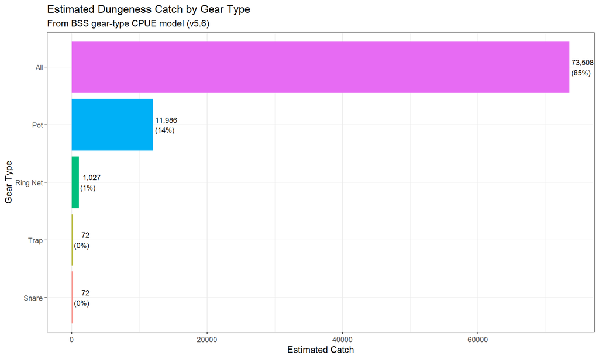

```r
write.csv(gear_port, file.path(output_dir, "catch_by_gear_type.csv"), row.names = FALSE)

# Gear type bar chart
p_gear <- gear_port |>
  mutate(gear_type = fct_reorder(gear_type, catch)) |>
  ggplot(aes(x = gear_type, y = catch, fill = gear_type)) +
  geom_col() +
  geom_text(aes(label = sprintf("%s\n(%.0f%%)", format(catch, big.mark=","), proportion*100)),
            hjust = -0.1, size = 3) +
  labs(title = "Estimated Dungeness Catch by Gear Type",
       subtitle = "From BSS gear-type CPUE model (v5.6)",
       x = "Gear Type", y = "Estimated Catch") +
  theme_bw() +
  theme(legend.position = "none") +
  coord_flip()
ggsave(file.path(output_dir, "plot_catch_by_gear_type.png"), p_gear, width = 10, height = 6)
print(p_gear)
```

```r
message("\n  Gear-type outputs saved.\n")
```

## 10. Convergence report

The per-fit diagnostic table behind the gate decision: R-hat and effective sample size for the summed effort and catch, the worst per-gear-type R-hat, the divergent fraction, and the pass/fail flag. **Healthy:** `pass_convergence` TRUE with R-hat near 1.00 and effective sample size well above 400 on every fit that had sufficient data.

```r
# ===========================================================================
# 7.11 CONVERGENCE REPORT
#
# v5.1: Extended diagnostics - checks C_sum_gear, r_C_gear, sigma_eps_C_gear
#        in addition to C_sum and E_sum (Issue 11)
# v5.2: Divergent transitions now included in pass/fail criterion.
#        Treedepth exceedance warnings added.
# ===========================================================================

message("\n", strrep("=",60), "\n CONVERGENCE REPORT\n", strrep("=",60), "\n")

convergence_report <- list()
for(label in names(bss_all)) {
  b <- bss_all[[label]]
  if(!is.null(b$pe_fallback) && b$pe_fallback) {
    convergence_report[[label]] <- tibble(
      fit = label, divergences = NA, treedepth_pct = NA,
      C_sum_rhat = NA, E_sum_rhat = NA, C_sum_neff = NA, E_sum_neff = NA,
      max_gear_rhat = NA, min_gear_neff = NA,
      max_r_C_rhat = NA, max_sigma_C_rhat = NA,
      pass_convergence = FALSE, method_selected = "PE (insufficient data)"
    )
  } else {
    sp <- rstan::get_sampler_params(b$fit, inc_warmup = FALSE)
    n_divergent <- sum(sapply(sp, function(x) sum(x[,"divergent__"])))
    n_treedepth <- sum(sapply(sp, function(x) sum(x[,"treedepth__"] >=
      b$fit@stan_args[[1]]$control$max_treedepth)))
    n_total <- sum(sapply(sp, nrow))

    # Core diagnostics: C_sum and E_sum
    summ_core <- summary(b$fit, pars = c("C_sum","E_sum"))$summary
    rhat_C <- summ_core["C_sum","Rhat"]; rhat_E <- summ_core["E_sum","Rhat"]
    neff_C <- summ_core["C_sum","n_eff"]; neff_E <- summ_core["E_sum","n_eff"]

    # v5.1 Extended: Per-gear-type diagnostics
    summ_gear <- summary(b$fit, pars = "C_sum_gear")$summary
    summ_r_C <- summary(b$fit, pars = "r_C_gear_out")$summary
    summ_sig_C <- summary(b$fit, pars = "sigma_eps_C_gear_out")$summary

    max_gear_rhat <- max(summ_gear[,"Rhat"], na.rm=TRUE)
    min_gear_neff <- min(summ_gear[,"n_eff"], na.rm=TRUE)
    max_r_C_rhat <- max(summ_r_C[,"Rhat"], na.rm=TRUE)
    max_sigma_C_rhat <- max(summ_sig_C[,"Rhat"], na.rm=TRUE)

    # Convergence criteria: ALL monitored parameters must pass
    all_rhats <- c(rhat_C, rhat_E, summ_gear[,"Rhat"],
                   summ_r_C[,"Rhat"], summ_sig_C[,"Rhat"])
    all_neffs <- c(neff_C, neff_E, summ_gear[,"n_eff"])

    pass_rhat <- max(all_rhats, na.rm=TRUE) < 1.01  # v5.4: tightened from 1.05 (Vehtari et al. 2021)
    pass_neff <- min(all_neffs, na.rm=TRUE) > 400
    # B1.8: the PE/BSS decision is the scale-aware gate (bss_compute_gate),
    # already computed and stored on the fit. Use it here so the report's
    # pass_convergence / method_selected match what actually selected PE vs BSS.
    # The gear-type diagnostics above are retained for insight; the divergence
    # fraction and impact values that drove the decision are printed to the
    # console by the gate and stored in b$gate_info.
    gi <- b$gate_info
    pass <- isTRUE(gi$pass_convergence)

    # v5.2: Warn on treedepth exceedances
    if(n_treedepth / n_total > 0.05) {
      message(sprintf("  WARNING: %s - %.1f%% treedepth exceedances (consider increasing max_treedepth)\n",
                  label, n_treedepth / n_total * 100))
    }
    # v5.2: Warn on divergences even if within threshold
    if(n_divergent > 0) {
      message(sprintf("  WARNING: %s - %d divergent transitions detected\n", label, n_divergent))
    }

    convergence_report[[label]] <- tibble(
      fit = label,
      divergences = n_divergent,
      treedepth_pct = round(n_treedepth / n_total * 100, 1),
      C_sum_rhat = round(rhat_C, 4),
      E_sum_rhat = round(rhat_E, 4),
      C_sum_neff = round(neff_C),
      E_sum_neff = round(neff_E),
      max_gear_rhat = round(max_gear_rhat, 4),
      min_gear_neff = round(min_gear_neff),
      max_r_C_rhat = round(max_r_C_rhat, 4),
      max_sigma_C_rhat = round(max_sigma_C_rhat, 4),
      pass_convergence = pass,
      method_selected = if(pass) "BSS" else "PE (convergence fail)"
    )

    # Warn if gear-type parameters failed but aggregates passed
    if(!pass && max(c(rhat_C, rhat_E), na.rm=TRUE) < 1.01) {
      message(sprintf("  WARNING: %s - C_sum/E_sum converged but gear-type parameters did not.\n", label))
      message(sprintf("    max gear Rhat=%.3f, max r_C Rhat=%.3f, max sigma_C Rhat=%.3f\n",
                  max_gear_rhat, max_r_C_rhat, max_sigma_C_rhat))
    }
  }
}
convergence_df <- bind_rows(convergence_report)

# F5: the scale-aware gate computed divergence_fraction, impact_C_sd, impact_E_sd
# and the four pass_* flags into b$gate_info, but the report above only carried
# `pass` and `method_selected`. Join the gate columns in so the CSV records WHY a
# component was routed to PE, matching the pooled driver's report.
gate_df <- bind_rows(lapply(names(bss_all), function(l) {
  gi <- bss_all[[l]]$gate_info
  if (is.null(gi)) return(NULL)
  gi |> select(any_of(c("fit","ar_resolution","divergence_fraction",
                        "impact_C_sd","impact_E_sd","distortion_C","distortion_E",
                        "pass_rhat","pass_neff","pass_div_fraction","pass_impact")))
}))
if (nrow(gate_df) > 0) {
  convergence_df <- convergence_df |>
    left_join(gate_df, by = "fit", suffix = c("", "_gate"))
}
message("\n")
report_table(convergence_df, caption = "Convergence and gate report")
```

Convergence and gate report

| fit | divergences | treedepth_pct | C_sum_rhat | E_sum_rhat | C_sum_neff | E_sum_neff | max_gear_rhat | min_gear_neff | max_r_C_rhat | max_sigma_C_rhat | pass_convergence | method_selected | ar_resolution | divergence_fraction | impact_C_sd | impact_E_sd | distortion_C | distortion_E | pass_rhat | pass_neff | pass_div_fraction | pass_impact |
| --- | --- | --- | --- | --- | --- | --- | --- | --- | --- | --- | --- | --- | --- | --- | --- | --- | --- | --- | --- | --- | --- | --- |
| shore_ring_net_only_Dungeness_Kept | 22 | 0 | 1 | 1 | 8,478 | 8,132 | 1 | 8,478 | 1 | 1 | TRUE | BSS | biweekly | 0 | 0 | 0 | 0.01 | 0.00 | TRUE | TRUE | TRUE | TRUE |
| shore_all_gear_Dungeness_Kept | 19 | 0 | 1 | 1 | 8,316 | 9,341 | 1 | 8,316 | 1 | 1 | TRUE | BSS | monthly | 0 | 0 | 0 | 0.02 | 0.01 | TRUE | TRUE | TRUE | TRUE |
| private_boat_ring_net_only_Dungeness_Kept | NA | NA | NA | NA | NA | NA | NA | NA | NA | NA | FALSE | PE (insufficient data) | NA | NA | NA | NA | NA | NA | FALSE | FALSE | FALSE | FALSE |
| private_boat_all_gear_Dungeness_Kept | 15 | 0 | 1 | 1 | 3,883 | 6,139 | 1 | 3,883 | 1 | 1 | TRUE | BSS | monthly | 0 | 0 | 0 | 0.00 | 0.01 | TRUE | TRUE | TRUE | TRUE |

```r
write.csv(convergence_df, file.path(output_dir, "convergence_report.csv"), row.names = FALSE)


# ===========================================================================
# 7.11b EXTENDED DIAGNOSTICS + PSIS-LOO
# Shared writers auto-sourced from 03_R_functions/:
#   write_bss_diagnostics()            structural params, divergence localization,
#                                      PPC calibration + PIT histogram
#   write_effort_overdispersion_diag()  Poisson / NB / latent variance decomposition
#   write_fit_extended_diagnostics()    O1-O9 (E-BFMI, AR paths, per-obs PIT,
#                                      prior-vs-posterior contraction, ...)
#   write_loo_diagnostics()             O13 PSIS-LOO + Pareto-k, from the
#                                      log_lik_gear/trailer/catch added to the
#                                      gear-resolved Stan model.
#
# These run for every fit that PRODUCED draws, including fits the convergence
# gate rejected. That is deliberate: a gate-failed fit reports PE in the totals,
# but its diagnostics are exactly what identify WHY it failed.
# ===========================================================================

message("\n", strrep("=",60), "\n EXTENDED DIAGNOSTICS\n", strrep("=",60), "\n")

for(label in names(bss_all)) {
  b <- bss_all[[label]]
  if(is.null(b$fit)) next   # PE-only (insufficient data): no draws to diagnose

  message(sprintf("\n--- diagnostics: %s (%s) ---\n", label,
              if(isTRUE(b$use_bss)) "gate PASS" else "gate FAIL -> reporting PE"))

  write_bss_diagnostics(b$fit, b$bss_data, label, output_dir)
  write_effort_overdispersion_diag(b$fit, b$bss_data, label, output_dir)
  write_fit_extended_diagnostics(b$fit, b$bss_data, b$days_ss, label, output_dir)
  write_loo_diagnostics(b$fit, b$bss_data, b$days_ss, label, output_dir)
  # F4: CPUE estimator triad, saturation exponent, and the E/h unit assertion.
  write_cpue_diagnostics(b, label, output_dir)
}
```

```
##     [diag] shore_ring_net_only_Dungeness_Kept: 22/8000 divergent (0.3%); distortion C/E = 1.0%/0.1%
##     [diag] PPC coverage (nominal 50/95):
##       gear     50%=58%  95%=98%  (n=52)
##       catch    50%=58%  95%=99%  (n=627)
```

```
##   shore_ring_net_only_Dungeness_Kept [gear]: n=52 | shares pois/NB/latent = 0.06/0.81/0.13 | pred VMR 15.03 (NB-only 13.29) | PPC cov50 0.58, pit_sd 0.261
##       -> observation NB over-dispersion dominates: lever is r_E / sigma_r_E prior (T1.5 5a; pair with T1.3)
```

```
##   WARNING: shore_ring_net_only_Dungeness_Kept - model CPUE 1.3146 sits 152% of the way from
##            ratio-of-sums (1.2567) toward mean-of-ratios (1.2948).
##            The NB dispersion is pulling lambda_C off the rate scale;
##            check the saturation exponent before trusting the total.
##   WARNING: shore_ring_net_only_Dungeness_Kept - saturation exponent beta = 0.274 (SE 0.065).
##            The likelihood assumes beta = 1 (catch proportional to h).
##            Effort-hours is NOT a valid unit here; use deployments.
```

```
##     [diag] shore_all_gear_Dungeness_Kept: 19/8000 divergent (0.2%); distortion C/E = 2.3%/0.8%
##     [diag] PPC coverage (nominal 50/95):
##       gear     50%=57%  95%=95%  (n=311)
##       catch    50%=73%  95%=98%  (n=1649)
```

```
##   shore_all_gear_Dungeness_Kept [gear]: n=311 | shares pois/NB/latent = 0.05/0.91/0.04 | pred VMR 15.94 (NB-only 15.33) | PPC cov50 0.57, pit_sd 0.278
##       -> observation NB over-dispersion dominates: lever is r_E / sigma_r_E prior (T1.5 5a; pair with T1.3)
##   WARNING: shore_all_gear_Dungeness_Kept - saturation exponent beta = 0.217 (SE 0.048).
##            The likelihood assumes beta = 1 (catch proportional to h).
##            Effort-hours is NOT a valid unit here; use deployments.
```

```
##     [diag] private_boat_all_gear_Dungeness_Kept: 15/4000 divergent (0.4%); distortion C/E = 0.2%/0.7%
##     [diag] PPC coverage (nominal 50/95):
##       trailer  50%=69%  95%=98%  (n=195)
##       catch    50%=60%  95%=98%  (n=131)
```

```
##   private_boat_all_gear_Dungeness_Kept [trailer]: n=195 | shares pois/NB/latent = 0.03/0.93/0.04 | pred VMR 13.85 (NB-only 13.37) | PPC cov50 0.69, pit_sd 0.268
##       -> observation NB over-dispersion dominates: lever is r_E / sigma_r_E prior (T1.5 5a; pair with T1.3)
```

```
##   WARNING: private_boat_all_gear_Dungeness_Kept - saturation exponent beta = 0.249 (SE 0.059).
##            The likelihood assumes beta = 1 (catch proportional to h).
##            Effort-hours is NOT a valid unit here; use deployments.
```

```r
# Run-level rollups (O10-O12). gear_props = NULL: the gear-resolved model carries
# gear composition via PE apportionment, not as a run-level Stan object, so O10
# is skipped for this track.
write_run_level_diagnostics(bss_all, pe_all, gear_props = NULL,
                            params = params, output_dir = output_dir)
```

```
##     [save:O7] skipped: no parameter C_expected
```

## 11. Daily combined estimate

The daily catch and effort series assembled from the fitted components, the fine-grained trajectory underneath the monthly roll-up.

```r
# ===========================================================================
# 7.12 DAILY COMBINED ESTIMATE
# v5.1: Uses C_total instead of C[S][D,G]
# ===========================================================================

message("\n", strrep("=",60), "\n DAILY COMBINED ESTIMATE\n", strrep("=",60), "\n")

daily_combined <- list()

for(pop in c("shore","private_boat")) {
  for(ss in subseasons) {
    label_cg <- paste0(pop, "_", ss$name, "_Dungeness_Kept")
    pe_label <- paste0(pop, "_", ss$name)
    b <- bss_all[[label_cg]]

    days_ss <- prep_days_crab(ss$start, ss$end, params, L_eff_model)
    summ_ss <- prep_population_summary(dwg, pop, ss$start, ss$end, params)

    pe_daily <- summ_ss$effort_index |>
      filter(count_sequence <= params$bss_max_count_seq) |>
      group_by(event_date) |>
      summarise(mean_count = mean(count_quantity), .groups = "drop") |>
      mutate(pe_effort = mean_count * summ_ss$crabbers_per_gear) |>
      left_join(days_ss |> select(event_date, day_type, day_length), by = "event_date") |>
      mutate(pe_crabber_hours = pe_effort * day_length)

    # v5.2: Apply incomplete trip filter to PE CPUE in daily combined
    pe_cpue_int <- summ_ss$interview |> filter(fishing_time_total > 0)
    if(isTRUE(params$filter_incomplete_trips)) {
      pe_cpue_int <- pe_cpue_int |> filter(trip_status == "Complete" | is.na(trip_status))
    }
    pe_cpue <- pe_cpue_int |>
      group_by(event_date) |>
      summarise(catch = sum(Dungeness_Kept, na.rm=TRUE),
                hrs = sum(fishing_time_total, na.rm=TRUE), .groups="drop") |>
      mutate(pe_cpue = if_else(hrs > 0, catch/hrs, NA_real_))

    daily_pop <- days_ss |>
      select(event_date, day_type, day_length) |>
      mutate(population = pop, subseason = ss$name) |>
      left_join(pe_daily |> select(event_date, pe_crabber_hours), by = "event_date") |>
      left_join(pe_cpue |> select(event_date, pe_cpue), by = "event_date") |>
      mutate(pe_catch = pe_crabber_hours * pe_cpue)

    if(!is.null(b) && !bss_use_pe_for(b)) {   # B1.8: BSS only if it passed the gate
      E_bss <- rstan::extract(b$fit, "E")$E
      # v5.2: C_total is now expected value (smooth, no Poisson noise).
      # Good for daily trajectory plots. Season totals use C_gear_pred.
      C_total_bss <- rstan::extract(b$fit, "C_total")$C_total  # [draws, D]

      daily_pop$bss_effort_median <- apply(E_bss[,1,,1], 2, median)
      daily_pop$bss_effort_lo95  <- apply(E_bss[,1,,1], 2, quantile, 0.025)
      daily_pop$bss_effort_hi95  <- apply(E_bss[,1,,1], 2, quantile, 0.975)
      daily_pop$bss_catch_median <- apply(C_total_bss, 2, median)
      daily_pop$bss_catch_lo95   <- apply(C_total_bss, 2, quantile, 0.025)
      daily_pop$bss_catch_hi95   <- apply(C_total_bss, 2, quantile, 0.975)

      conv <- convergence_df |> filter(fit == label_cg)
      use_bss <- nrow(conv) > 0 && conv$pass_convergence[1]

      daily_pop$combined_effort <- if(use_bss) daily_pop$bss_effort_median else daily_pop$pe_crabber_hours
      daily_pop$combined_catch  <- if(use_bss) daily_pop$bss_catch_median  else daily_pop$pe_catch
      daily_pop$method <- if(use_bss) "BSS" else "PE"
    } else {
      daily_pop$bss_effort_median <- NA; daily_pop$bss_effort_lo95 <- NA; daily_pop$bss_effort_hi95 <- NA
      daily_pop$bss_catch_median <- NA; daily_pop$bss_catch_lo95 <- NA; daily_pop$bss_catch_hi95 <- NA
      daily_pop$combined_effort <- daily_pop$pe_crabber_hours
      daily_pop$combined_catch  <- daily_pop$pe_catch
      daily_pop$method <- "PE"
    }

    daily_combined[[length(daily_combined)+1]] <- daily_pop
  }
}
```

```
##
##   shore [2024-09-16 to 2024-11-30]: 52 effort obs, 856 interviews, crab/gear=0.76, R_G_empirical=1.32
##
##   shore [2024-12-01 to 2025-09-15]: 313 effort obs, 2743 interviews, crab/gear=0.79, R_G_empirical=1.27
##
##   private_boat [2024-09-16 to 2024-11-30]: 44 effort obs, 17 interviews, crab/gear=0.79, R_G_empirical=1.26
##
##   private_boat [2024-12-01 to 2025-09-15]: 196 effort obs, 145 interviews, crab/gear=0.82, R_G_empirical=1.22
```

```r
daily_combined_df <- bind_rows(daily_combined) |>
  mutate(across(where(is.numeric), ~round(., 1))) |>
  arrange(event_date, population)

message(sprintf("  Daily combined estimate: %d rows (%d days x %d populations)\n",
            nrow(daily_combined_df), n_distinct(daily_combined_df$event_date),
            n_distinct(daily_combined_df$population)))
write.csv(daily_combined_df, file.path(output_dir, "daily_combined_estimate.csv"), row.names = FALSE)
```

## 12. Per-fit data coverage

How much observed data each fit rests on: latent days, effort observations, interviews, and the percent of days carrying any data. **Healthy:** read the thin-coverage fits (few interviews, low percent of days sampled) as the ones leaning hardest on the AR process and priors.

```r
# ===========================================================================
# 7.13 DATA COVERAGE TABLE
# ===========================================================================

message("\n", strrep("=",60), "\n DATA COVERAGE\n", strrep("=",60), "\n")

coverage <- list()
for(pop in c("shore","private_boat")) {
  for(ss in subseasons) {
    days_ss <- prep_days_crab(ss$start, ss$end, params, L_eff_model)
    summ_ss <- prep_population_summary(dwg, pop, ss$start, ss$end, params)

    days_ss$month_label <- format(days_ss$event_date, "%Y-%m")

    total_days <- days_ss |> count(month_label, name = "total_days")

    effort_days <- summ_ss$effort_index |>
      mutate(month_label = format(event_date, "%Y-%m")) |>
      distinct(event_date, month_label) |>
      count(month_label, name = "effort_days")

    int_days <- summ_ss$interview |>
      mutate(month_label = format(event_date, "%Y-%m")) |>
      distinct(event_date, month_label) |>
      count(month_label, name = "interview_days")

    int_count <- summ_ss$interview |>
      mutate(month_label = format(event_date, "%Y-%m")) |>
      count(month_label, name = "n_interviews")

    cov <- total_days |>
      left_join(effort_days, by = "month_label") |>
      left_join(int_days, by = "month_label") |>
      left_join(int_count, by = "month_label") |>
      mutate(across(c(effort_days, interview_days, n_interviews), ~replace_na(., 0)),
             effort_coverage_pct = round(effort_days / total_days * 100, 0),
             population = pop, subseason = ss$name)

    coverage[[length(coverage)+1]] <- cov
  }
}
```

```
##
##   shore [2024-09-16 to 2024-11-30]: 52 effort obs, 856 interviews, crab/gear=0.76, R_G_empirical=1.32
##
##   shore [2024-12-01 to 2025-09-15]: 313 effort obs, 2743 interviews, crab/gear=0.79, R_G_empirical=1.27
##
##   private_boat [2024-09-16 to 2024-11-30]: 44 effort obs, 17 interviews, crab/gear=0.79, R_G_empirical=1.26
##
##   private_boat [2024-12-01 to 2025-09-15]: 196 effort obs, 145 interviews, crab/gear=0.82, R_G_empirical=1.22
```

```r
coverage_df <- bind_rows(coverage) |>
  select(population, subseason, month_label, total_days, effort_days, effort_coverage_pct,
         interview_days, n_interviews) |>
  arrange(population, month_label)

message("\n")
report_table(coverage_df, caption = "Per-fit data coverage")
```

Per-fit data coverage

| population | subseason | month_label | total_days | effort_days | effort_coverage_pct | interview_days | n_interviews |
| --- | --- | --- | --- | --- | --- | --- | --- |
| private_boat | ring_net_only | 2024-09 | 15 | 7 | 47 | 3 | 3 |
| private_boat | ring_net_only | 2024-10 | 31 | 21 | 68 | 8 | 11 |
| private_boat | ring_net_only | 2024-11 | 30 | 15 | 50 | 2 | 3 |
| private_boat | all_gear | 2024-12 | 31 | 22 | 71 | 17 | 40 |
| private_boat | all_gear | 2025-01 | 31 | 21 | 68 | 15 | 35 |
| private_boat | all_gear | 2025-02 | 28 | 17 | 61 | 4 | 5 |
| private_boat | all_gear | 2025-03 | 31 | 18 | 58 | 2 | 6 |
| private_boat | all_gear | 2025-04 | 30 | 14 | 47 | 7 | 11 |
| private_boat | all_gear | 2025-05 | 31 | 14 | 45 | 7 | 11 |
| private_boat | all_gear | 2025-06 | 30 | 6 | 20 | 3 | 6 |
| private_boat | all_gear | 2025-07 | 31 | 9 | 29 | 4 | 8 |
| private_boat | all_gear | 2025-08 | 31 | 14 | 45 | 7 | 16 |
| private_boat | all_gear | 2025-09 | 15 | 8 | 53 | 5 | 7 |
| shore | ring_net_only | 2024-09 | 15 | 9 | 60 | 9 | 146 |
| shore | ring_net_only | 2024-10 | 31 | 23 | 74 | 23 | 343 |
| shore | ring_net_only | 2024-11 | 30 | 20 | 67 | 19 | 367 |
| shore | all_gear | 2024-12 | 31 | 22 | 71 | 23 | 373 |
| shore | all_gear | 2025-01 | 31 | 21 | 68 | 21 | 310 |
| shore | all_gear | 2025-02 | 28 | 17 | 61 | 17 | 186 |
| shore | all_gear | 2025-03 | 31 | 19 | 61 | 19 | 247 |
| shore | all_gear | 2025-04 | 30 | 14 | 47 | 14 | 347 |
| shore | all_gear | 2025-05 | 31 | 14 | 45 | 14 | 284 |
| shore | all_gear | 2025-06 | 30 | 6 | 20 | 6 | 138 |
| shore | all_gear | 2025-07 | 31 | 9 | 29 | 9 | 220 |
| shore | all_gear | 2025-08 | 31 | 14 | 45 | 14 | 419 |
| shore | all_gear | 2025-09 | 15 | 9 | 60 | 9 | 219 |

```r
write.csv(coverage_df, file.path(output_dir, "data_coverage.csv"), row.names = FALSE)
```

## 13. Effort and CPUE multipliers

The fitted structural quantities that shape the daily series: the weekend effort effect (B1), the holiday effort effect (B2), and the interview CPUE summary by month and population.

```r
# ===========================================================================
# 7.14 EFFORT MULTIPLIER SUMMARY (B1, B2)
# ===========================================================================

message("\n", strrep("=",60), "\n EFFORT MULTIPLIERS (B1, B2)\n", strrep("=",60), "\n")

multiplier_results <- list()
for(label in names(bss_all)) {
  b <- bss_all[[label]]
  if(is.null(b$pe_fallback) || !b$pe_fallback) {
    B1_draws <- rstan::extract(b$fit, "B1")$B1
    B2_draws <- rstan::extract(b$fit, "B2")$B2

    weekend_mult <- exp(B1_draws)
    holiday_mult <- exp(B1_draws + B2_draws)

    multiplier_results[[label]] <- tibble(
      fit = label,
      B1_median = round(median(B1_draws), 3),
      B1_lo95 = round(quantile(B1_draws, 0.025), 3),
      B1_hi95 = round(quantile(B1_draws, 0.975), 3),
      weekend_multiplier = sprintf("%.1fx (%.1f-%.1f)",
        median(weekend_mult), quantile(weekend_mult, 0.025), quantile(weekend_mult, 0.975)),
      B2_median = round(median(B2_draws), 3),
      B2_lo95 = round(quantile(B2_draws, 0.025), 3),
      B2_hi95 = round(quantile(B2_draws, 0.975), 3),
      holiday_multiplier = sprintf("%.1fx (%.1f-%.1f)",
        median(holiday_mult), quantile(holiday_mult, 0.025), quantile(holiday_mult, 0.975))
    )
  }
}
if(length(multiplier_results) > 0) {
  multiplier_df <- bind_rows(multiplier_results)
  message("\n  Effort multipliers relative to weekdays:\n")
  for(i in 1:nrow(multiplier_df)) {
    message(sprintf("    %s:\n      Weekends: %s\n      Holidays: %s\n",
                multiplier_df$fit[i],
                multiplier_df$weekend_multiplier[i],
                multiplier_df$holiday_multiplier[i]))
  }
  write.csv(multiplier_df, file.path(output_dir, "effort_multipliers.csv"), row.names = FALSE)
}


# ===========================================================================
# 7.15 INTERVIEW CPUE SUMMARY BY MONTH x POPULATION
# ===========================================================================

message("\n", strrep("=",60), "\n INTERVIEW CPUE SUMMARY\n", strrep("=",60), "\n")

cpue_summary <- dwg$interview |>
  filter(fishing_time_total > 0, population %in% c("shore","private_boat")) |>
  mutate(
    month_label = format(event_date, "%Y-%m"),
    cpue = dungeness_kept / fishing_time_total
  ) |>
  group_by(population, month_label) |>
  summarise(
    n_interviews = n(),
    mean_cpue = round(mean(cpue, na.rm=TRUE), 3),
    sd_cpue = round(sd(cpue, na.rm=TRUE), 3),
    se_cpue = round(sd(cpue, na.rm=TRUE) / sqrt(n()), 3),
    median_cpue = round(median(cpue, na.rm=TRUE), 3),
    mean_dungeness = round(mean(dungeness_kept, na.rm=TRUE), 1),
    mean_hours = round(mean(fishing_time_total, na.rm=TRUE), 1),
    .groups = "drop"
  ) |>
  arrange(population, month_label)

message("\n")
report_table(cpue_summary, caption = "Interview CPUE summary by month")
```

Interview CPUE summary by month

| population | month_label | n_interviews | mean_cpue | sd_cpue | se_cpue | median_cpue | mean_dungeness | mean_hours |
| --- | --- | --- | --- | --- | --- | --- | --- | --- |
| private_boat | 2024-09 | 3 | 0.33 | 0.58 | 0.33 | 0.00 | 2.0 | 6.0 |
| private_boat | 2024-10 | 11 | 1.22 | 0.99 | 0.30 | 1.07 | 6.2 | 5.9 |
| private_boat | 2024-11 | 3 | 3.67 | 2.08 | 1.20 | 3.00 | 12.0 | 5.0 |
| private_boat | 2024-12 | 40 | 1.44 | 1.73 | 0.27 | 0.50 | 16.2 | 44.6 |
| private_boat | 2025-01 | 35 | 1.54 | 1.45 | 0.24 | 1.20 | 14.6 | 60.9 |
| private_boat | 2025-02 | 5 | 0.79 | 1.30 | 0.58 | 0.00 | 4.0 | 13.5 |
| private_boat | 2025-03 | 6 | 0.43 | 0.59 | 0.24 | 0.17 | 4.8 | 9.7 |
| private_boat | 2025-04 | 11 | 1.45 | 1.30 | 0.39 | 1.00 | 5.0 | 6.6 |
| private_boat | 2025-05 | 11 | 0.59 | 0.57 | 0.17 | 0.56 | 11.7 | 91.4 |
| private_boat | 2025-06 | 6 | 0.46 | 0.76 | 0.31 | 0.18 | 5.3 | 44.2 |
| private_boat | 2025-07 | 8 | 0.52 | 0.66 | 0.23 | 0.21 | 5.5 | 70.1 |
| private_boat | 2025-08 | 16 | 0.64 | 0.77 | 0.19 | 0.23 | 7.9 | 42.9 |
| private_boat | 2025-09 | 7 | 0.31 | 0.33 | 0.13 | 0.20 | 3.1 | 19.1 |
| shore | 2024-09 | 146 | 0.68 | 1.75 | 0.14 | 0.37 | 3.4 | 7.8 |
| shore | 2024-10 | 343 | 0.58 | 0.70 | 0.04 | 0.42 | 3.5 | 7.3 |
| shore | 2024-11 | 367 | 0.65 | 0.74 | 0.04 | 0.46 | 3.4 | 6.2 |
| shore | 2024-12 | 373 | 0.58 | 0.76 | 0.04 | 0.33 | 3.1 | 6.6 |
| shore | 2025-01 | 310 | 0.24 | 0.40 | 0.02 | 0.00 | 1.6 | 7.2 |
| shore | 2025-02 | 186 | 0.27 | 0.50 | 0.04 | 0.00 | 1.3 | 7.2 |
| shore | 2025-03 | 247 | 0.29 | 0.54 | 0.03 | 0.10 | 1.5 | 6.9 |
| shore | 2025-04 | 347 | 0.28 | 0.45 | 0.02 | 0.13 | 2.3 | 11.5 |
| shore | 2025-05 | 284 | 0.43 | 0.62 | 0.04 | 0.21 | 2.5 | 8.2 |
| shore | 2025-06 | 138 | 0.36 | 0.47 | 0.04 | 0.17 | 2.7 | 10.1 |
| shore | 2025-07 | 220 | 0.29 | 0.43 | 0.03 | 0.08 | 2.2 | 9.1 |
| shore | 2025-08 | 419 | 0.35 | 0.54 | 0.03 | 0.10 | 2.3 | 8.3 |
| shore | 2025-09 | 219 | 0.46 | 0.63 | 0.04 | 0.20 | 3.1 | 8.3 |

```r
write.csv(cpue_summary, file.path(output_dir, "interview_cpue_summary.csv"), row.names = FALSE)
```

## 14. Expansion ratios (R_G and R_G_boat)

The gear-per-crabber ratio (shore) and gear-per-boat-group ratio (boat) that carry effort onto the gear-deployment scale. **Healthy:** the shore R_G is data-identified (a tight interval near ~1.3 gear per crabber); the boat R_G is prior-driven (no gear counts in boat fits), so read its wide interval as expected, not a failure.

```r
# ===========================================================================
# 7.16 R_G AND R_G_boat POSTERIOR SUMMARIES
# v5.3: Stan model now exposes R_G_boat (gear per boat group) in place of
#       R_T (trailers per group). For shore fits R_G_boat is sampled from
#       its prior but has no data attached, so it is reported only for
#       boat fits. For boat fits R_G is fixed at params$R_G_fixed_boat.
# v5.1: Notes R_G behavior for boat vs shore fits
# ===========================================================================

message("\n", strrep("=",60), "\n EXPANSION RATIO POSTERIORS (R_G, R_G_boat)\n", strrep("=",60), "\n")

expansion_results <- list()
for(label in names(bss_all)) {
  b <- bss_all[[label]]
  if(is.null(b$pe_fallback) || !b$pe_fallback) {
    R_G_draws <- rstan::extract(b$fit, "R_G")$R_G

    # R_G_boat is only data-informed for boat fits; report it there.
    # F5: R_G is NEVER fixed. estimate_R_G and R_G_fixed are not declared in the
    # Stan model (rstan ignores them), so R_G is always a parameter. In a boat fit
    # Gear_n = 0, so R_G has no likelihood and simply samples its lognormal prior.
    # The old label said "fixed at 1.30", which was false.
    is_shore_fit <- grepl("^shore_", label)
    R_G_status <- if(is_shore_fit) "estimated (gear counts)" else "prior-only (no gear counts in boat fits)"

    if(!is_shore_fit) {
      R_G_boat_draws <- rstan::extract(b$fit, "R_G_boat")$R_G_boat
      R_G_boat_median <- round(median(R_G_boat_draws), 3)
      R_G_boat_lo95   <- round(quantile(R_G_boat_draws, 0.025), 3)
      R_G_boat_hi95   <- round(quantile(R_G_boat_draws, 0.975), 3)
      R_G_boat_interp <- sprintf("%.2f gear per boat group (%.2f-%.2f)",
        R_G_boat_median, R_G_boat_lo95, R_G_boat_hi95)
    } else {
      R_G_boat_median <- NA_real_
      R_G_boat_lo95   <- NA_real_
      R_G_boat_hi95   <- NA_real_
      R_G_boat_interp <- "not applicable (shore fit)"
    }

    expansion_results[[label]] <- tibble(
      fit = label,
      R_G_median = round(median(R_G_draws), 3),
      R_G_lo95 = round(quantile(R_G_draws, 0.025), 3),
      R_G_hi95 = round(quantile(R_G_draws, 0.975), 3),
      R_G_status = R_G_status,
      R_G_interpretation = sprintf("%.2f gear per crabber (%.2f-%.2f) [%s]",
        median(R_G_draws), quantile(R_G_draws, 0.025), quantile(R_G_draws, 0.975), R_G_status),
      R_G_boat_median = R_G_boat_median,
      R_G_boat_lo95 = R_G_boat_lo95,
      R_G_boat_hi95 = R_G_boat_hi95,
      R_G_boat_interpretation = R_G_boat_interp
    )
  }
}
if(length(expansion_results) > 0) {
  expansion_df <- bind_rows(expansion_results)
  message("\n")
  for(i in 1:nrow(expansion_df)) {
    message(sprintf("  %s:\n    R_G:      %s\n    R_G_boat: %s\n",
                expansion_df$fit[i],
                expansion_df$R_G_interpretation[i],
                expansion_df$R_G_boat_interpretation[i]))
  }
  write.csv(expansion_df, file.path(output_dir, "expansion_ratios.csv"), row.names = FALSE)
}
```

## 15. PE vs BSS comparison

Side by side, the design-based PE and the Bayesian BSS for each component. **How to read it:** close agreement is reassuring; a large gap on a component means the two methods disagree there, usually because that component is data-thin, and the BSS interval width tells you how well-identified it is. Since both run on the same effort unit, a remaining gap is a genuine model disagreement, not a unit artifact.

```r
# ===========================================================================
# 7.17 PE VS BSS COMPARISON TABLE
# ===========================================================================

message("\n", strrep("=",60), "\n PE VS BSS COMPARISON (by component)\n", strrep("=",60), "\n")

comparison <- list()
for(pop in c("shore","private_boat")) {
  for(ss in subseasons) {
    label_cg <- paste0(pop, "_", ss$name, "_Dungeness_Kept")
    pe_label <- paste0(pop, "_", ss$name)
    b <- bss_all[[label_cg]]

    pe_catch <- pe_all[[pe_label]]$Dungeness_Kept %||% 0
    pe_effort <- pe_all[[pe_label]]$effort_total %||% 0

    if(!is.null(b) && (is.null(b$pe_fallback) || !b$pe_fallback)) {
      bss_catch <- b$C_sum["50%"]
      bss_effort <- b$E_sum["50%"]
      catch_diff_pct <- round((bss_catch - pe_catch) / pe_catch * 100, 1)
      effort_diff_pct <- round((bss_effort - pe_effort) / pe_effort * 100, 1)

      conv <- convergence_df |> filter(fit == label_cg)
      method <- if(nrow(conv) > 0 && conv$pass_convergence[1]) "BSS" else "PE"
    } else {
      bss_catch <- NA; bss_effort <- NA
      catch_diff_pct <- NA; effort_diff_pct <- NA
      method <- "PE"
    }

    comparison[[length(comparison)+1]] <- tibble(
      component = paste0(pop, " (", ss$display_name, ")"),
      PE_effort = round(pe_effort),
      BSS_effort = round(bss_effort),
      effort_diff_pct = effort_diff_pct,
      PE_catch = round(pe_catch),
      BSS_catch = round(bss_catch),
      catch_diff_pct = catch_diff_pct,
      method_selected = method
    )
  }
}

comparison[[length(comparison)+1]] <- tibble(
  component = "comm_charter (census)",
  PE_effort = round(pe_all$comm_charter$effort_total),
  BSS_effort = NA, effort_diff_pct = NA,
  PE_catch = round(pe_all$comm_charter$Dungeness_Kept),
  BSS_catch = NA, catch_diff_pct = NA,
  method_selected = "Census"
)

comparison_df <- bind_rows(comparison)
message("\n")
report_table(comparison_df, caption = "PE vs BSS by component")
```

PE vs BSS by component

| component | PE_effort | BSS_effort | effort_diff_pct | PE_catch | BSS_catch | catch_diff_pct | method_selected |
| --- | --- | --- | --- | --- | --- | --- | --- |
| shore (Pot closure) | 4,486 | 4,760 | 6.1 | 5,869 | 6,258 | 6.6 | BSS |
| shore (All gear) | 18,104 | 23,617 | 30.4 | 15,665 | 20,124 | 28.5 | BSS |
| private_boat (Pot closure) | 584 | NA | NA | 1,170 | NA | NA | PE |
| private_boat (All gear) | 11,886 | 16,266 | 36.9 | 36,468 | 47,126 | 29.2 | BSS |
| comm_charter (census) | 283 | NA | NA | 11,986 | NA | NA | Census |

```r
write.csv(comparison_df, file.path(output_dir, "pe_vs_bss_comparison.csv"), row.names = FALSE)
```

## 16. Season summary

Run-level metadata: the season window, sampling coverage, interview count, how many fits passed the gate, and the mode split, a one-page header for the run.

```r
# ===========================================================================
# 7.18 SEASON SUMMARY ONE-PAGER
# ===========================================================================

message("\n", strrep("=",60), "\n SEASON SUMMARY\n", strrep("=",60), "\n")

port_total_cg <- "Dungeness_Kept"
pt_file <- file.path(output_dir, paste0("port_total_", port_total_cg, ".csv"))
if(file.exists(pt_file)) {
  port_total <- read.csv(pt_file)
} else {
  port_total <- tibble(Estimate = c("Effort","Catch"), PE = NA, BSS_median = NA, BSS_lo95 = NA, BSS_hi95 = NA)
}

mode_catch <- c(
  Shore = round(pe_pop_sum("shore", "Dungeness_Kept")),
  `Private Boat` = round(pe_pop_sum("private_boat", "Dungeness_Kept")),
  `Commercial/Charter` = round(pe_all$comm_charter$Dungeness_Kept %||% 0)
)
mode_pct <- round(mode_catch / sum(mode_catch) * 100, 1)

monthly_file <- file.path(output_dir, "monthly_estimates.csv")
top_months <- if(file.exists(monthly_file)) {
  read.csv(monthly_file) |>
    arrange(desc(BSS_Catch_median)) |>
    head(5) |>
    mutate(label = sprintf("%s: %s crab", Month, format(BSS_Catch_median, big.mark=","))) |>
    pull(label)
} else { "Monthly estimates not available" }

n_bss_fits <- sum(!sapply(bss_all, function(b) !is.null(b$pe_fallback) && b$pe_fallback))
n_pass <- sum(convergence_df$pass_convergence, na.rm=TRUE)

total_effort_days <- n_distinct(c(dwg$shore_effort$event_date, dwg$boat_effort$event_date))
total_interview_n <- nrow(dwg$interview)
season_days <- as.integer(as.Date(params$est_date_end) - as.Date(params$est_date_start) + 1)

message("\n  ╔══════════════════════════════════════════════════════╗\n")
message("  ║         SEASON SUMMARY: 2024-25 GRAYS HARBOR        ║\n")
message("  ╠══════════════════════════════════════════════════════╣\n")
message(sprintf("  ║  Season: %s to %s (%d days)   ║\n",
            params$est_date_start, params$est_date_end, season_days))
message("  ╠══════════════════════════════════════════════════════╣\n")
message("  ║  PORT TOTAL (Dungeness Kept)                        ║\n")
if(nrow(port_total) >= 2) {
  message(sprintf("  ║    PE:  %s crab                              ║\n",
              format(port_total$PE[2], big.mark=",")))
  if(!is.na(port_total$BSS_median[2])) {
    message(sprintf("  ║    BSS: %s crab (%s - %s)        ║\n",
                format(port_total$BSS_median[2], big.mark=","),
                format(port_total$BSS_lo95[2], big.mark=","),
                format(port_total$BSS_hi95[2], big.mark=",")))
  }
}
message("  ╠══════════════════════════════════════════════════════╣\n")
message("  ║  HARVEST BY MODE                                    ║\n")
for(nm in names(mode_catch)) {
  message(sprintf("  ║    %-20s %6s (%4.1f%%)             ║\n",
              nm, format(mode_catch[nm], big.mark=","), mode_pct[nm]))
}
message("  ╠══════════════════════════════════════════════════════╣\n")
message("  ║  TOP HARVEST MONTHS                                 ║\n")
for(m in top_months[1:min(5, length(top_months))]) {
  message(sprintf("  ║    %s\n", m))
}
message("  ╠══════════════════════════════════════════════════════╣\n")
message("  ║  DATA QUALITY                                       ║\n")
message(sprintf("  ║    Effort sampling: %d of %d days (%d%%)            ║\n",
            total_effort_days, season_days, round(total_effort_days/season_days*100)))
message(sprintf("  ║    Interviews: %s total                        ║\n",
            format(total_interview_n, big.mark=",")))
message(sprintf("  ║    BSS convergence: %d of %d fits passed          ║\n",
            n_pass, n_bss_fits))
message("  ╚══════════════════════════════════════════════════════╝\n")

season_summary <- tibble(
  metric = c("Season start", "Season end", "Season days",
             "PE total catch", "BSS total catch (median)", "BSS 95% CI lower", "BSS 95% CI upper",
             paste("Catch (PE):", names(mode_catch)), paste("Catch % (PE):", names(mode_catch)),
             "Effort days sampled", "Total interviews",
             "BSS fits attempted", "BSS fits passed convergence"),
  value = c(params$est_date_start, params$est_date_end, as.character(season_days),
            if(nrow(port_total)>=2) as.character(c(port_total$PE[2], port_total$BSS_median[2],
              port_total$BSS_lo95[2], port_total$BSS_hi95[2])) else rep(NA, 4),
            as.character(mode_catch), as.character(mode_pct),
            as.character(total_effort_days), as.character(total_interview_n),
            as.character(n_bss_fits), as.character(n_pass))
)
write.csv(season_summary, file.path(output_dir, "season_summary.csv"), row.names = FALSE)

report_table(season_summary,
  caption = "Season summary. The headline is the BSS gated total; the by-mode Catch (PE) rows are design-based Point Estimates and sum to the PE total, not the BSS total.")
```

Season summary. The headline is the BSS gated total; the by-mode Catch (PE) rows are design-based Point Estimates and sum to the PE total, not the BSS total.

| metric | value |
| --- | --- |
| Season start | 2024-09-16 |
| Season end | 2025-09-15 |
| Season days | 365 |
| PE total catch | 71157 |
| BSS total catch (median) | 86817 |
| BSS 95% CI lower | 73424 |
| BSS 95% CI upper | 105724 |
| Catch (PE): Shore | 21533 |
| Catch (PE): Private Boat | 37638 |
| Catch (PE): Commercial/Charter | 11986 |
| Catch % (PE): Shore | 30.3 |
| Catch % (PE): Private Boat | 52.9 |
| Catch % (PE): Commercial/Charter | 16.8 |
| Effort days sampled | 200 |
| Total interviews | 3925 |
| BSS fits attempted | 3 |
| BSS fits passed convergence | 3 |

```r
message("\n  New output tables saved.\n")
```

## 17. Incomplete-trip sensitivity

How much dropping incomplete trips (gear not yet retrieved at the interview) moves each component’s PE. **Healthy:** dropping incomplete trips raises the estimate (soaking gear reads low mid-trip); a component that moves the other way is worth a second look.

```r
# ===========================================================================
# 7.19 SENSITIVITY: INCOMPLETE TRIP EFFECT ON PE ESTIMATES
#
# v5.2: Compares PE estimates with and without the incomplete trip filter
#        to quantify the harvest impact. Reports per-population, per-sub-season,
#        and per-gear-type CPUE differences.
# ===========================================================================

timer_start("7_sensitivity")
message("\n", strrep("=",60), "\n SENSITIVITY: INCOMPLETE TRIP EFFECT\n", strrep("=",60), "\n")

sensitivity_results <- list()

for(pop in c("shore","private_boat")) {
  for(ss in subseasons) {
    label <- paste0(pop, "_", ss$name)
    days_ss <- prep_days_crab(ss$start, ss$end, params, L_eff_model)
    summ_ss <- prep_population_summary(dwg, pop, ss$start, ss$end, params)

    # Count trip status
    n_total_int <- nrow(summ_ss$interview)
    n_complete <- sum(summ_ss$interview$trip_status == "Complete", na.rm=TRUE)
    n_incomplete <- sum(summ_ss$interview$trip_status == "Incomplete", na.rm=TRUE)
    n_missing_ts <- sum(is.na(summ_ss$interview$trip_status))

    # PE with all trips
    params_all <- params; params_all$filter_incomplete_trips <- FALSE
    pe_all_trips <- run_pe_gear(summ_ss, days_ss, params_all, paste0(label, " [all trips]"),
                           population = pop)

    # PE with completed trips only
    params_comp <- params; params_comp$filter_incomplete_trips <- TRUE
    summ_comp <- summ_ss
    summ_comp$interview <- summ_ss$interview |>
      filter(trip_status == "Complete" | is.na(trip_status))
    pe_complete <- run_pe_gear(summ_comp, days_ss, params_comp, paste0(label, " [complete only]"),
                          population = pop)

    diff_pct <- if(pe_all_trips$Dungeness_Kept > 0) {
      (pe_complete$Dungeness_Kept - pe_all_trips$Dungeness_Kept) /
        pe_all_trips$Dungeness_Kept * 100
    } else { NA }

    message(sprintf("  %s: All=%s, Complete=%s (diff=%+.1f%%)\n",
                label,
                format(round(pe_all_trips$Dungeness_Kept), big.mark=","),
                format(round(pe_complete$Dungeness_Kept), big.mark=","),
                diff_pct))

    sensitivity_results[[length(sensitivity_results)+1]] <- tibble(
      component = label,
      n_interviews_total = n_total_int,
      n_complete = n_complete,
      n_incomplete = n_incomplete,
      n_missing_status = n_missing_ts,
      pct_incomplete = round(n_incomplete / max(n_complete + n_incomplete, 1) * 100, 1),
      PE_catch_all_trips = round(pe_all_trips$Dungeness_Kept),
      PE_catch_complete_only = round(pe_complete$Dungeness_Kept),
      diff_pct = round(diff_pct, 1),
      filter_applied = isTRUE(params$filter_incomplete_trips)
    )
  }
}
```

```
##
##   shore [2024-09-16 to 2024-11-30]: 52 effort obs, 856 interviews, crab/gear=0.76, R_G_empirical=1.32
##   PE check [shore_ring_net_only [all trips] / Dungeness_Kept]: implied CPUE 1.1963 vs interview ratio-of-sums 1.1670 (1.03x) [gear-deployments]
##   PE shore_ring_net_only [all trips]: Effort=4,486 gear-deployments, Dung=5,366
##   PE check [shore_ring_net_only [complete only] / Dungeness_Kept]: implied CPUE 1.3083 vs interview ratio-of-sums 1.2567 (1.04x) [gear-deployments]
##   PE shore_ring_net_only [complete only]: Effort=4,486 gear-deployments, Dung=5,869
```

```
##
##   shore [2024-12-01 to 2025-09-15]: 313 effort obs, 2743 interviews, crab/gear=0.79, R_G_empirical=1.27
##   PE check [shore_all_gear [all trips] / Dungeness_Kept]: implied CPUE 0.7748 vs interview ratio-of-sums 0.7711 (1.00x) [gear-deployments]
##   PE shore_all_gear [all trips]: Effort=18,104 gear-deployments, Dung=14,026
##   PE check [shore_all_gear [complete only] / Dungeness_Kept]: implied CPUE 0.8653 vs interview ratio-of-sums 0.8706 (0.99x) [gear-deployments]
##   PE shore_all_gear [complete only]: Effort=18,104 gear-deployments, Dung=15,665
```

```
##
##   private_boat [2024-09-16 to 2024-11-30]: 44 effort obs, 17 interviews, crab/gear=0.79, R_G_empirical=1.26
##   PE boat scale: gear_per_group=2.82, tau=1.20, mean f=1.000 (deployments, crab-directed)
##   PE check [private_boat_ring_net_only [all trips] / Dungeness_Kept]: implied CPUE 2.0037 vs interview ratio-of-sums 2.2917 (0.87x) [gear-deployments]
##   PE private_boat_ring_net_only [all trips]: Effort=584 gear-deployments, Dung=1,170
##   PE boat scale: gear_per_group=2.82, tau=1.20, mean f=1.000 (deployments, crab-directed)
##   PE check [private_boat_ring_net_only [complete only] / Dungeness_Kept]: implied CPUE 2.0037 vs interview ratio-of-sums 2.2917 (0.87x) [gear-deployments]
##   PE private_boat_ring_net_only [complete only]: Effort=584 gear-deployments, Dung=1,170
```

```
##
##   private_boat [2024-12-01 to 2025-09-15]: 196 effort obs, 145 interviews, crab/gear=0.82, R_G_empirical=1.22
##   PE boat scale: gear_per_group=3.55, tau=1.20, mean f=1.000 (deployments, crab-directed)
##   PE check [private_boat_all_gear [all trips] / Dungeness_Kept]: implied CPUE 2.9193 vs interview ratio-of-sums 3.1359 (0.93x) [gear-deployments]
##   PE private_boat_all_gear [all trips]: Effort=11,886 gear-deployments, Dung=34,699
##   PE boat scale: gear_per_group=3.55, tau=1.20, mean f=1.000 (deployments, crab-directed)
##   PE check [private_boat_all_gear [complete only] / Dungeness_Kept]: implied CPUE 3.0682 vs interview ratio-of-sums 3.3570 (0.91x) [gear-deployments]
##   PE private_boat_all_gear [complete only]: Effort=11,879 gear-deployments, Dung=36,446
```

```r
sensitivity_df <- bind_rows(sensitivity_results)
message("\n")
report_table(sensitivity_df, caption = "Incomplete-trip sensitivity (PE catch)")
```

Incomplete-trip sensitivity (PE catch)

| component | n_interviews_total | n_complete | n_incomplete | n_missing_status | pct_incomplete | PE_catch_all_trips | PE_catch_complete_only | diff_pct | filter_applied |
| --- | --- | --- | --- | --- | --- | --- | --- | --- | --- |
| shore_ring_net_only | 856 | 627 | 229 | 0 | 26.8 | 5,366 | 5,869 | 9.4 | TRUE |
| shore_all_gear | 2,743 | 1,647 | 1,091 | 5 | 39.8 | 14,026 | 15,665 | 11.7 | TRUE |
| private_boat_ring_net_only | 17 | 17 | 0 | 0 | 0.0 | 1,170 | 1,170 | 0.0 | TRUE |
| private_boat_all_gear | 145 | 131 | 14 | 0 | 9.7 | 34,699 | 36,446 | 5.0 | TRUE |

```r
write.csv(sensitivity_df, file.path(output_dir, "sensitivity_incomplete_trips.csv"), row.names = FALSE)

# Gear-type-specific CPUE comparison (shore only, all sub-seasons combined)
message("\n--- Gear-Type CPUE: Complete vs Incomplete (Shore) ---\n")
shore_int <- dwg$interview |>
  filter(population == "shore",
         between(event_date, as.Date(params$est_date_start), as.Date(params$est_date_end)),
         fishing_time_total >= 0.5) |>
  mutate(
    cpue = dungeness_kept / fishing_time_total,
    has_pot      = as.integer(str_detect(gear_type, "(?i)\\bpot\\b") &
                              !str_detect(gear_type, "(?i)\\bslip\\s*ring\\b")),
    has_ring_net = as.integer(str_detect(gear_type, "(?i)\\bring\\s*net\\b")),
    has_trap     = as.integer(str_detect(gear_type, "(?i)\\b(trap|star)\\b")),
    has_snare    = as.integer(str_detect(gear_type, "(?i)\\bsnare\\b")),
    n_gear_types = pmax(has_pot + has_ring_net + has_trap + has_snare, 1L)
  )

gear_sensitivity <- list()
for(gname in c("Pot","Ring Net","Trap","Snare")) {
  gcol <- c(Pot="has_pot", `Ring Net`="has_ring_net", Trap="has_trap", Snare="has_snare")[gname]
  gdata <- shore_int |> filter(.data[[gcol]] == 1, n_gear_types == 1)  # single-gear only
  if(nrow(gdata) < 10) next
  by_status <- gdata |>
    group_by(trip_status) |>
    summarise(mean_cpue = mean(cpue), n = n(), .groups = "drop")
  cpue_c <- by_status |> filter(trip_status == "Complete") |> pull(mean_cpue)
  cpue_i <- by_status |> filter(trip_status == "Incomplete") |> pull(mean_cpue)
  n_c <- by_status |> filter(trip_status == "Complete") |> pull(n)
  n_i <- by_status |> filter(trip_status == "Incomplete") |> pull(n)
  if(length(cpue_c) > 0 && length(cpue_i) > 0 && cpue_c > 0) {
    bias <- (cpue_i - cpue_c) / cpue_c * 100
    message(sprintf("  %10s: Complete=%.3f (n=%d), Incomplete=%.3f (n=%d), Bias=%+.1f%%\n",
                gname, cpue_c, n_c, cpue_i, n_i, bias))
    gear_sensitivity[[length(gear_sensitivity)+1]] <- tibble(
      gear_type = gname, cpue_complete = round(cpue_c, 3), n_complete = n_c,
      cpue_incomplete = round(cpue_i, 3), n_incomplete = n_i,
      bias_pct = round(bias, 1)
    )
  }
}
if(length(gear_sensitivity) > 0) {
  gear_sens_df <- bind_rows(gear_sensitivity)
  write.csv(gear_sens_df, file.path(output_dir, "sensitivity_incomplete_by_gear.csv"), row.names = FALSE)
}
timer_stop("7_sensitivity")
```

```
##   [TIMER] 7_sensitivity: 0.0 min
```

```r
# ---- 7.20 SAVE PARAMETERS ----
timer_stop("6_outputs")
```

```
##   [TIMER] 6_outputs: 1.1 min
```

```r
writeLines(capture.output(str(params)), file.path(output_dir, "run_parameters.txt"))

message(sprintf("\nAll outputs saved to: %s\n", output_dir))
message(paste(" ", list.files(output_dir), collapse="\n"), "\n")

# ---- TIMING SUMMARY ----
run_total <- difftime(Sys.time(), run_start_time, units = "mins")
message("\n", strrep("=",60), "\n TIMING SUMMARY\n", strrep("=",60), "\n")
timing_df <- tibble(
  Section = names(bss_timer_log()),
  Minutes = sapply(bss_timer_log(), function(x) round(as.numeric(x$elapsed), 1))
)
report_table(timing_df, caption = "Run timing summary")
```

Run timing summary

| Section | Minutes |
| --- | --- |
| 1_load_data | 0.0 |
| 2_diagnostic_plots | 0.1 |
| 3_PE_estimates | 0.0 |
| 4_commercial_charter | 0.0 |
| 5_BSS_model_runs | 12.8 |
| BSS_shore_ring_net_only_Dungeness_Kept | 1.8 |
| BSS_shore_all_gear_Dungeness_Kept | 7.8 |
| BSS_private_boat_all_gear_Dungeness_Kept | 2.3 |
| 6_outputs | 1.1 |
| 7_sensitivity | 0.0 |

```r
message(sprintf("\n  TOTAL RUNTIME: %.1f minutes (%.1f hours)\n",
            as.numeric(run_total), as.numeric(run_total)/60))
```

## Model diagnostics (tables)

Per-fit diagnostic tables, surfaced on the page so the gear-resolved report matches the pooled driver’s HTML output. Each table reads a CSV the run already wrote via the shared writers in `03_R_functions/` (during the driver chunk above); a missing file renders nothing rather than interrupting the report. These are display-only and change no estimate.

### Per-fit convergence summary

Per-fit convergence summary (key gate columns; full detail in convergence_report.csv). Div frac is the divergent-transition fraction (backstop 0.05); Impact C/E (SD) is the scale-aware gating criterion (threshold 0.10); max gear R-hat is the worst per-gear-type R-hat (gear-resolved only); Method is what the totals actually use. Healthy: R-hat near 1.00, min n_eff above 400, Pass = TRUE.

| Fit | AR | Div | Div frac | R-hat C | R-hat E | max gear R-hat | min n_eff | Impact C (SD) | Impact E (SD) | Pass | Method |
| --- | --- | --- | --- | --- | --- | --- | --- | --- | --- | --- | --- |
| shore pot-closure | biweekly | 22 | 0.003 | 1 | 1 | 1 | 8,132 | 0.000 | 0 | TRUE | BSS |
| shore all-gear | monthly | 19 | 0.002 | 1 | 1 | 1 | 8,316 | 0.001 | 0 | TRUE | BSS |
| boat pot-closure | NA | NA | NA | NA | NA | NA | NA | NA | NA | FALSE | PE (insufficient data) |
| boat all-gear | monthly | 15 | 0.004 | 1 | 1 | 1 | 3,883 | 0.000 | 0 | TRUE | BSS |

### Posterior-predictive calibration

Posterior-predictive coverage and PIT for each fit and data stream, written per fit during the run.

Posterior-predictive calibration by fit and data stream. Healthy: Cover 95% near 0.95 and PIT mean near 0.50; coverage well above nominal means the predictive is too wide (over-dispersed), the effort streams are the known case.

| Fit | Stream | Cover 50% | Cover 95% | PIT mean | PIT sd | n |
| --- | --- | --- | --- | --- | --- | --- |
| boat all-gear | trailer | 0.69 | 0.98 | 0.49 | 0.27 | 195 |
| boat all-gear | catch | 0.60 | 0.98 | 0.51 | 0.27 | 131 |
| shore all-gear | gear | 0.57 | 0.95 | 0.50 | 0.28 | 311 |
| shore all-gear | catch | 0.73 | 0.98 | 0.50 | 0.28 | 1,649 |
| shore pot-closure | gear | 0.58 | 0.98 | 0.51 | 0.26 | 52 |
| shore pot-closure | catch | 0.58 | 0.99 | 0.51 | 0.30 | 627 |

### Effort over-dispersion decomposition

Splits each effort-count predictive variance into its Poisson floor, negative-binomial observation over-dispersion, and latent-process parts, per fit.

Effort-count predictive variance decomposition (shares sum to 1): Poisson floor, negative-binomial observation over-dispersion, and latent AR-process variance. The dominant share is the lever to tune if the effort predictive is too wide.

| Fit | Stream | Poisson | NB overdisp | Latent AR | Cover 50% |
| --- | --- | --- | --- | --- | --- |
| boat all-gear | trailer | 0.03 | 0.93 | 0.04 | 0.69 |
| shore all-gear | gear | 0.05 | 0.91 | 0.04 | 0.57 |
| shore pot-closure | gear | 0.06 | 0.81 | 0.13 | 0.58 |

### Extended per-fit outputs and PSIS-LOO

CPUE effort-unit validity, per-fit data coverage, and PSIS-LOO cross-validation, read back from the CSVs written during the run.

CPUE effort-unit validity. beta_h is the catch-vs-effort elasticity (harvest- unbiased when it covers 1, shown as ‘linear? = ok’); the model CPUE should track the design-based ratio-of-sums (RoS). ‘sat? = FLAG’ (catch sub-linear in soak time) is expected for pots and is the reason the unit is deployments, not hours.

| Fit | Unit | n | CPUE RoS | CPUE model | beta_h | linear? | sat beta | sat? |
| --- | --- | --- | --- | --- | --- | --- | --- | --- |
| boat all-gear | gear-deployments | 131 | 3.36 | 2.90 | 0.75 | ok | 0.25 | FLAG |
| shore all-gear | gear-deployments | 1,649 | 0.87 | 0.85 | 1.05 | ok | 0.22 | FLAG |
| shore pot-closure | gear-deployments | 627 | 1.26 | 1.31 | 0.92 | ok | 0.27 | FLAG |

Per-fit data coverage: latent days, effort observations, interviews, and I/E observations, with the percent of days carrying any effort/interview data. Thin coverage is where the BSS leans hardest on the AR process and priors.

| Fit | Method | AR | Days | Eff obs | Interviews | I/E obs | % days eff | % days int |
| --- | --- | --- | --- | --- | --- | --- | --- | --- |
| shore pot-closure | BSS | biweekly | 76 | 52 | 627 | 0 | 68 | 67 |
| shore all-gear | BSS | monthly | 289 | 311 | 1,649 | 4 | 50 | 50 |
| boat pot-closure | PE (insufficient data) | NA | NA | NA | NA | NA | NA | NA |
| boat all-gear | BSS | monthly | 289 | 195 | 131 | 0 | 50 | 23 |

PSIS-LOO by data stream. p_loo is the effective number of parameters; a large ‘Pareto k>0.7’ count means LOO is unreliable for that stream (the model is near- saturated there), so read its elpd_loo with caution.

| Fit | Stream | n | elpd_loo | p_loo | Pareto k>0.7 |
| --- | --- | --- | --- | --- | --- |
| boat all-gear | trailer | 195 | -561.0 | 8.4 | 0 |
| boat all-gear | catch | 131 | -451.6 | 10.5 | 1 |
| shore all-gear | gear | 311 | -1,393.3 | 11.1 | 0 |
| shore all-gear | catch | 1,649 | -3,190.0 | 9.8 | 0 |
| shore pot-closure | gear | 52 | -228.2 | 6.3 | 1 |
| shore pot-closure | catch | 627 | -1,448.6 | 6.0 | 0 |

### Summer-extrapolation transparency

How much of each fitted component’s BSS catch falls on days with **no interview**, where the CPUE is imputed by the AR process and priors rather than observed. A high extrapolated share means that component’s harvest rests on the model filling unsampled time; read it as a coverage diagnostic, not a re-estimate of the total.

Share of each fitted component’s BSS catch on days with no interview (CPUE imputed by the AR process). Across the fitted components, 68.9% of the summed BSS catch falls on extrapolated days. A high ‘% catch extrapolated’ flags a component whose harvest rests on the model filling unsampled time; shares use summed daily medians, so read as a coverage diagnostic, not a re-estimate of the total.

| Fit | days total | days sampled | catch total | catch extrapolated | % days sampled | % catch extrapolated |
| --- | --- | --- | --- | --- | --- | --- |
| boat all-gear | 289 | 66 | 43,310 | 35,100 | 23 | 81.0 |
| shore all-gear | 289 | 145 | 19,048 | 10,015 | 50 | 52.6 |
| shore pot-closure | 76 | 51 | 5,861 | 1,864 | 67 | 31.8 |